# Tarea 1 Estadística y Probabilidad

Diana Laura Pais Felipe Matrícula:23-002-0030

18 septiembre, 2025

# Ejercicio 6: Variables Nominales

## Ejercicio 6.1 Sexo

### Datos

```r
sexo <- c("NA", "NA", "NA", "Femenino", "NA", "Femenino", "Femenino", "Femenino", "NA", "Masculino","Femenino", "Femenino", "Masculino", "Femenino", "NA", "Masculino", "NA", "NA", "Masculino", "Masculino", "Masculino", "Masculino", "NA", "Femenino", "NA")
```

### Procesamiento de datos

Primero obtenemos un resumen de los datos generados

```r
summary(sexo)
```

```
##    Length     Class      Mode
##        25 character character
```

Al ser variables de tipo Nominal no se pueden ordenar ni se pueden obtener los deciles ni cuartiles.

### Frecuencias

Obtenemos las frecuencias de los datos.

```r
(sexo) #Datos
```

```
##  [1] "NA"        "NA"        "NA"        "Femenino"  "NA"        "Femenino"
##  [7] "Femenino"  "Femenino"  "NA"        "Masculino" "Femenino"  "Femenino"
## [13] "Masculino" "Femenino"  "NA"        "Masculino" "NA"        "NA"
## [19] "Masculino" "Masculino" "Masculino" "Masculino" "NA"        "Femenino"
## [25] "NA"
```

```r
sort(sexo) #Datos ordenados por clase
```

```
##  [1] "Femenino"  "Femenino"  "Femenino"  "Femenino"  "Femenino"  "Femenino"
##  [7] "Femenino"  "Femenino"  "Masculino" "Masculino" "Masculino" "Masculino"
## [13] "Masculino" "Masculino" "Masculino" "NA"        "NA"        "NA"
## [19] "NA"        "NA"        "NA"        "NA"        "NA"        "NA"
## [25] "NA"
```

```r
contador <- table(sexo) #Frecuencia de los datos
(contador)
```

```
## sexo
##  Femenino Masculino        NA
##         8         7        10
```

### Proporciones

Obtenemos las proporciones.

```r
prop.table(table(sexo)) #Proporciones
```

```
## sexo
##  Femenino Masculino        NA
##      0.32      0.28      0.40
```

### Medidas de tendencia central

Obtenemos la moda

```r
# Función para detectar modalidad
max_frecuencia <- max(contador)
modas <- names(contador)[contador == max_frecuencia]

# Identificar e imprimir resultado
if(length(modas) == 1) {
  cat("UNIMODAL - Moda:", modas)
} else if(length(modas) == 2) {
  cat("BIMODAL - Modas:", paste(modas, collapse = " y "))
} else {
  cat("Hay más de dos clases con mayor frecuencia por lo tanto no hay moda")
}
```

```
## UNIMODAL - Moda: NA
```

### Gráficos

Comenzamos a graficar.

#### Gráfica con el comando *barplot*

Generemos la gráfica de barras.

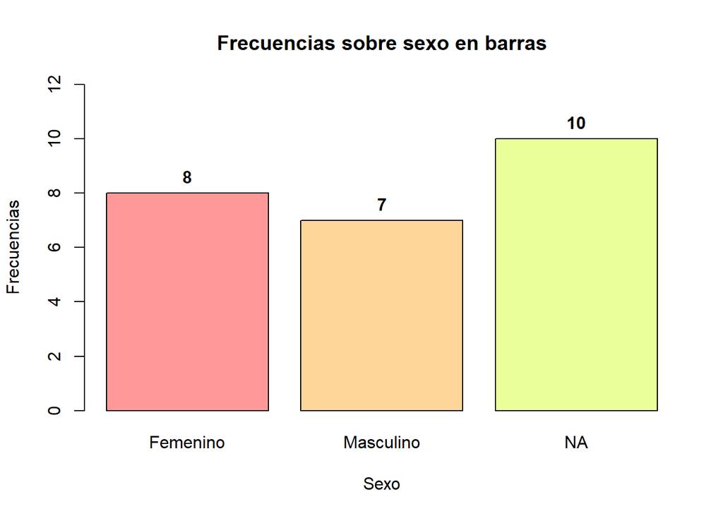

```r
gb<-barplot(contador, col=rainbow(10,0.4),
        main="Frecuencias sobre sexo en barras",
        xlab="Sexo",
        ylab="Frecuencias",
        ylim=c(0,12),
        )
# Agregar valores encima de cada barra
text(x=gb,
     y=contador,
     labels=contador,
     pos=3,
     cex=1,
     font=2)
```

#### Gráfica de porcentajes

Generamos la gráfica de porcentajes.

```r
tabla <- table(sexo); (tabla)
```

```
## sexo
##  Femenino Masculino        NA
##         8         7        10
```

```r
porcentajes <-  round(prop.table(tabla)* 100, 1); (porcentajes)
```

```
## sexo
##  Femenino Masculino        NA
##        32        28        40
```

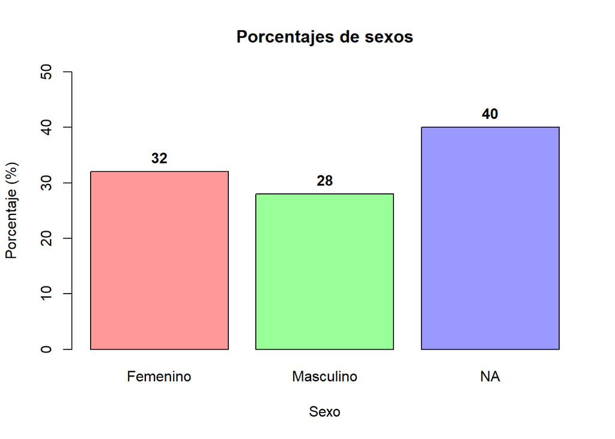

```r
gp<- barplot(porcentajes, col = rainbow(length(tabla),0.4),
    main = "Porcentajes de sexos",
    xlab = "Sexo",
    ylab="Porcentaje (%)",
    ylim=c(0,50),
        )
# Agregar valores encima de cada barra
text(x=gp,
     y=porcentajes,
     labels=porcentajes,
     pos=3,
     cex=1,
     font=2)
```

#### Gráfica de pasteles

Generamos la gráfica de pasteles.

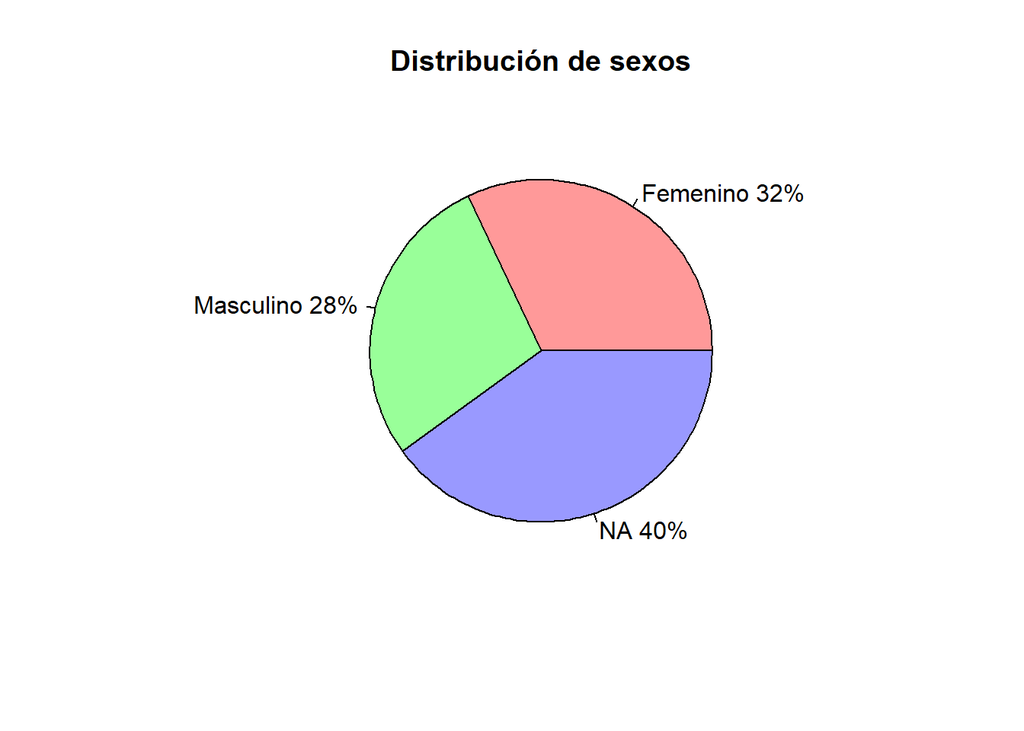

```r
pie(tabla,
    main = "Distribución de sexos",
    col = rainbow(length(tabla),0.4),
    labels = paste0(names(tabla)," ",porcentajes, "%"))
```

```r
#---- Fin ----
```

## Ejercicio 6.2 Nacionalidad

### Datos

```r
nacionalidad <- c("Boliviana", "Peruana", "Venezolana", "Cubana", "Mexicana", "Colombiana", "Colombiana", "Brasileña", "Colombiana", "Venezolana", "Chilena", "Argentina", "Mexicana", "Mexicana", "Argentina", "Mexicana", "Argentina", "Brasileña", "Mexicana", "Uruguaya", "Argentina", "Argentina", "Colombiana", "Cubana", "Boliviana", "Peruana", "Boliviana", "Boliviana", "Peruana", "Uruguaya", "Chilena", "Uruguaya", "Venezolana", "Uruguaya", "Argentina", "Venezolana", "Uruguaya", "Cubana", "Venezolana", "Cubana", "Chilena", "Argentina", "Peruana",
"Boliviana", "Cubana", "Venezolana", "Colombiana", "Mexicana", "Uruguaya", "Argentina")
```

### Procesamiento de datos

Primero obtenemos un resumen de los datos generados

```r
summary(nacionalidad)
```

```
##    Length     Class      Mode
##        50 character character
```

Al ser variables de tipo Nominal no se pueden ordenar ni se pueden obtener los deciles ni cuartiles.

### Frecuencias

Obtenemos las frecuencias de los datos.

```r
(nacionalidad) #Datos
```

```
##  [1] "Boliviana"  "Peruana"    "Venezolana" "Cubana"     "Mexicana"
##  [6] "Colombiana" "Colombiana" "Brasileña"  "Colombiana" "Venezolana"
## [11] "Chilena"    "Argentina"  "Mexicana"   "Mexicana"   "Argentina"
## [16] "Mexicana"   "Argentina"  "Brasileña"  "Mexicana"   "Uruguaya"
## [21] "Argentina"  "Argentina"  "Colombiana" "Cubana"     "Boliviana"
## [26] "Peruana"    "Boliviana"  "Boliviana"  "Peruana"    "Uruguaya"
## [31] "Chilena"    "Uruguaya"   "Venezolana" "Uruguaya"   "Argentina"
## [36] "Venezolana" "Uruguaya"   "Cubana"     "Venezolana" "Cubana"
## [41] "Chilena"    "Argentina"  "Peruana"    "Boliviana"  "Cubana"
## [46] "Venezolana" "Colombiana" "Mexicana"   "Uruguaya"   "Argentina"
```

```r
sort(nacionalidad) #Datos ordenados por clase
```

```
##  [1] "Argentina"  "Argentina"  "Argentina"  "Argentina"  "Argentina"
##  [6] "Argentina"  "Argentina"  "Argentina"  "Boliviana"  "Boliviana"
## [11] "Boliviana"  "Boliviana"  "Boliviana"  "Brasileña"  "Brasileña"
## [16] "Chilena"    "Chilena"    "Chilena"    "Colombiana" "Colombiana"
## [21] "Colombiana" "Colombiana" "Colombiana" "Cubana"     "Cubana"
## [26] "Cubana"     "Cubana"     "Cubana"     "Mexicana"   "Mexicana"
## [31] "Mexicana"   "Mexicana"   "Mexicana"   "Mexicana"   "Peruana"
## [36] "Peruana"    "Peruana"    "Peruana"    "Uruguaya"   "Uruguaya"
## [41] "Uruguaya"   "Uruguaya"   "Uruguaya"   "Uruguaya"   "Venezolana"
## [46] "Venezolana" "Venezolana" "Venezolana" "Venezolana" "Venezolana"
```

```r
contador <- table(nacionalidad) #Frecuencia de los datos
(contador)
```

```
## nacionalidad
##  Argentina  Boliviana  Brasileña    Chilena Colombiana     Cubana   Mexicana
##          8          5          2          3          5          5          6
##    Peruana   Uruguaya Venezolana
##          4          6          6
```

### Proporciones

Obtenemos las proporciones.

```r
prop.table(table(nacionalidad)) #Proporciones
```

```
## nacionalidad
##  Argentina  Boliviana  Brasileña    Chilena Colombiana     Cubana   Mexicana
##       0.16       0.10       0.04       0.06       0.10       0.10       0.12
##    Peruana   Uruguaya Venezolana
##       0.08       0.12       0.12
```

### Medidas de tendencia central

Obtenemos la moda

```r
# Función para detectar modalidad
max_frecuencia <- max(contador)
modas <- names(contador)[contador == max_frecuencia]

# Identificar e imprimir resultado
if(length(modas) == 1) {
  cat("UNIMODAL - Moda:", modas)
} else if(length(modas) == 2) {
  cat("BIMODAL - Modas:", paste(modas, collapse = " y "))
} else {
  cat("Hay más de dos clases con mayor frecuencia por lo tanto no hay moda")
}
```

```
## UNIMODAL - Moda: Argentina
```

### Gráficos

Comenzamos a graficar.

#### Gráfica con el comando *barplot*

Generemos la gráfica de barras.

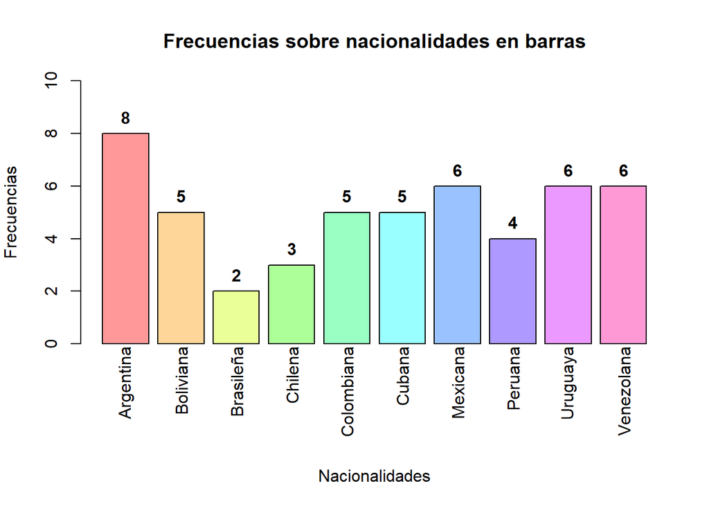

```r
par(mar=c(8,4,4,2))
gb<-barplot(contador, col=rainbow(10,0.4),
        main="Frecuencias sobre nacionalidades en barras",
        xlab="",
        names.arg="",
        ylab="Frecuencias",
        ylim=c(0,10),
        )
title(xlab="Nacionalidades",line=6)

#Etiquetas rotadas
text(x=gb,
     y=par("usr")[3]-0.1,
     labels=names(contador),
     srt=90,
     adj=1,
     xpd=TRUE,
     cex=1)

# Agregar valores encima de cada barra
text(x=gb,
     y=contador,
     labels=contador,
     pos=3,
     cex=1,
     font=2)
```

#### Gráfica de porcentajes

Generamos la gráfica de porcentajes.

```r
par(mar=c(8,4,4,2))
tabla <- table(nacionalidad); (tabla)
```

```
## nacionalidad
##  Argentina  Boliviana  Brasileña    Chilena Colombiana     Cubana   Mexicana
##          8          5          2          3          5          5          6
##    Peruana   Uruguaya Venezolana
##          4          6          6
```

```r
porcentajes <-  round(prop.table(tabla)* 100, 1); (porcentajes)
```

```
## nacionalidad
##  Argentina  Boliviana  Brasileña    Chilena Colombiana     Cubana   Mexicana
##         16         10          4          6         10         10         12
##    Peruana   Uruguaya Venezolana
##          8         12         12
```

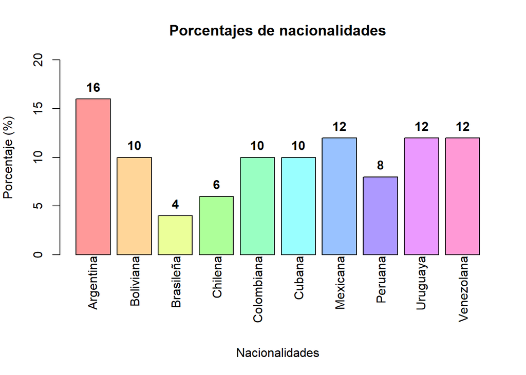

```r
gp<- barplot(porcentajes, col = rainbow(length(tabla),0.4),
    main = "Porcentajes de nacionalidades",
    xlab = "",
    names.arg="",
    ylab="Porcentaje (%)",
    ylim=c(0,20),
        )

title(xlab="Nacionalidades",line=6)

#Etiquetas rotadas
text(x=gb,
     y=par("usr")[3]-0.1,
     labels=names(contador),
     srt=90,
     adj=1,
     xpd=TRUE,
     cex=1)

# Agregar valores encima de cada barra
text(x=gp,
     y=porcentajes,
     labels=porcentajes,
     pos=3,
     cex=1,
     font=2)
```

#### Gráfica de pasteles

Generamos la gráfica de pasteles.

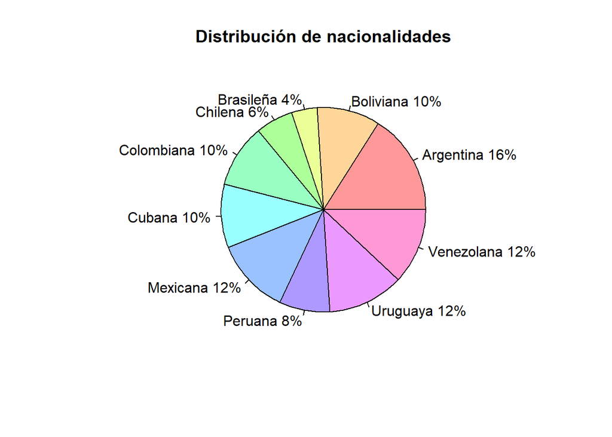

```r
pie(tabla,
    main = "Distribución de nacionalidades",
    col = rainbow(length(tabla),0.4),
    labels = paste0(names(tabla)," ",porcentajes, "%"))
```

```r
#---- Fin ----
```

## Ejercicio 6.3 Color de ojos

### Datos

```r
color_ojos <- c("Gris", "Azul", "Ambar", "Negro", "Avellana", "Café", "Avellana", "Azul", "Verde",
"Ambar", "Avellana", "Café", "Café", "Azul", "Verde", "Azul", "Avellana", "Verde", "Verde", "Verde",
"Gris", "Negro", "Avellana", "Negro", "Gris", "Negro", "Avellana", "Azul", "Ambar", "Verde")
```

### Procesamiento de datos

Primero obtenemos un resumen de los datos generados

```r
summary(color_ojos)
```

```
##    Length     Class      Mode
##        30 character character
```

Al ser variables de tipo Nominal no se pueden ordenar ni se pueden obtener los deciles ni cuartiles.

### Frecuencias

Obtenemos las frecuencias de los datos.

```r
(color_ojos) #Datos
```

```
##  [1] "Gris"     "Azul"     "Ambar"    "Negro"    "Avellana" "Café"
##  [7] "Avellana" "Azul"     "Verde"    "Ambar"    "Avellana" "Café"
## [13] "Café"     "Azul"     "Verde"    "Azul"     "Avellana" "Verde"
## [19] "Verde"    "Verde"    "Gris"     "Negro"    "Avellana" "Negro"
## [25] "Gris"     "Negro"    "Avellana" "Azul"     "Ambar"    "Verde"
```

```r
sort(color_ojos) #Datos ordenados por clase
```

```
##  [1] "Ambar"    "Ambar"    "Ambar"    "Avellana" "Avellana" "Avellana"
##  [7] "Avellana" "Avellana" "Avellana" "Azul"     "Azul"     "Azul"
## [13] "Azul"     "Azul"     "Café"     "Café"     "Café"     "Gris"
## [19] "Gris"     "Gris"     "Negro"    "Negro"    "Negro"    "Negro"
## [25] "Verde"    "Verde"    "Verde"    "Verde"    "Verde"    "Verde"
```

```r
contador <- table(color_ojos) #Frecuencia de los datos
(contador)
```

```
## color_ojos
##    Ambar Avellana     Azul     Café     Gris    Negro    Verde
##        3        6        5        3        3        4        6
```

### Proporciones

Obtenemos las proporciones.

```r
prop.table(table(color_ojos)) #Proporciones
```

```
## color_ojos
##     Ambar  Avellana      Azul      Café      Gris     Negro     Verde
## 0.1000000 0.2000000 0.1666667 0.1000000 0.1000000 0.1333333 0.2000000
```

### Medidas de tendencia central

Obtenemos la moda

```r
# Función para detectar modalidad
max_frecuencia <- max(contador)
modas <- names(contador)[contador == max_frecuencia]

# Identificar e imprimir resultado
if(length(modas) == 1) {
  cat("UNIMODAL - Moda:", modas)
} else if(length(modas) == 2) {
  cat("BIMODAL - Modas:", paste(modas, collapse = " y "))
} else {
  cat("Hay más de dos clases con mayor frecuencia por lo tanto no hay moda")
}
```

```
## BIMODAL - Modas: Avellana y Verde
```

### Gráficos

Comenzamos a graficar.

#### Gráfica con el comando *barplot*

Generemos la gráfica de barras.

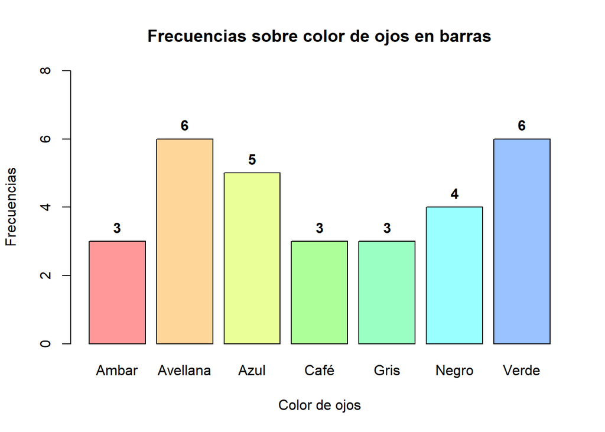

```r
gb<-barplot(contador, col=rainbow(10,0.4),
        main="Frecuencias sobre color de ojos en barras",
        xlab="Color de ojos",
        ylab="Frecuencias",
        ylim=c(0,8),
        )
# Agregar valores encima de cada barra
text(x=gb,
     y=contador,
     labels=contador,
     pos=3,
     cex=1,
     font=2)
```

#### Gráfica de porcentajes

Generamos la gráfica de porcentajes.

```r
tabla <- table(color_ojos); (tabla)
```

```
## color_ojos
##    Ambar Avellana     Azul     Café     Gris    Negro    Verde
##        3        6        5        3        3        4        6
```

```r
porcentajes <-  round(prop.table(tabla)* 100, 1); (porcentajes)
```

```
## color_ojos
##    Ambar Avellana     Azul     Café     Gris    Negro    Verde
##     10.0     20.0     16.7     10.0     10.0     13.3     20.0
```

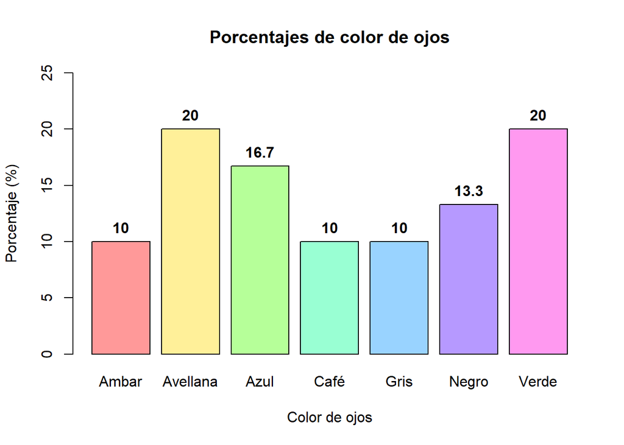

```r
gp<- barplot(porcentajes, col = rainbow(length(tabla),0.4),
    main = "Porcentajes de color de ojos",
    xlab = "Color de ojos",
    ylab="Porcentaje (%)",
    ylim=c(0,25),
        )
# Agregar valores encima de cada barra
text(x=gp,
     y=porcentajes,
     labels=porcentajes,
     pos=3,
     cex=1,
     font=2)
```

#### Gráfica de pasteles

Generamos la gráfica de pasteles.

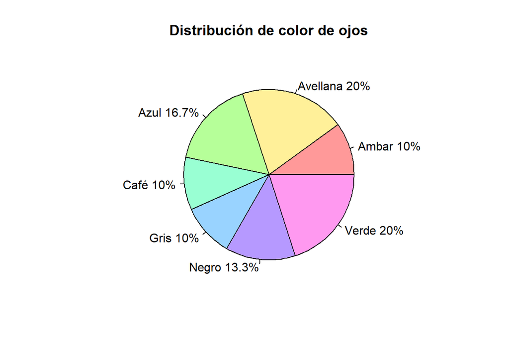

```r
pie(tabla,
    main = "Distribución de color de ojos",
    col = rainbow(length(tabla),0.4),
    labels = paste0(names(tabla)," ",porcentajes, "%"))
```

```r
#---- Fin ----
```

## Ejercicio 6.4 Marca de celular

### Datos

```r
marca <- c("Apple", "Samsung", "LG", "Huawei", "OnePlus", "Sony", "Apple", "Samsung",
"Huawei", "Huawei", "Nokia", "OnePlus", "Motorola", "Xiaomi", "Samsung", "Apple", "Apple", "Motorola",
"Samsung", "Samsung", "Huawei", "Motorola", "Nokia", "OnePlus", "Huawei", "Huawei",
"Apple", "LG", "Apple", "Xiaomi", "LG", "OnePlus", "OnePlus", "LG", "Sony", "Samsung", "Apple",
"Xiaomi", "Oppo", "Motorola", "LG", "Samsung", "Motorola", "Samsung", "Nokia", "OnePlus", "OnePlus", "Oppo", "Sony", "Nokia", "Huawei", "LG", "Sony", "Xiaomi", "LG", "Huawei", "LG", "Nokia",
"Xiaomi", "Sony", "OnePlus", "LG", "Xiaomi", "OnePlus", "Oppo", "Nokia", "Huawei", "Xiaomi", "Oppo",
"Oppo")
```

### Procesamiento de datos

Primero obtenemos un resumen de los datos generados

```r
summary(marca)
```

```
##    Length     Class      Mode
##        70 character character
```

Al ser variables de tipo Nominal no se pueden ordenar ni se pueden obtener los deciles ni cuartiles.

### Frecuencias

Obtenemos las frecuencias de los datos.

```r
(marca) #Datos
```

```
##  [1] "Apple"    "Samsung"  "LG"       "Huawei"   "OnePlus"  "Sony"
##  [7] "Apple"    "Samsung"  "Huawei"   "Huawei"   "Nokia"    "OnePlus"
## [13] "Motorola" "Xiaomi"   "Samsung"  "Apple"    "Apple"    "Motorola"
## [19] "Samsung"  "Samsung"  "Huawei"   "Motorola" "Nokia"    "OnePlus"
## [25] "Huawei"   "Huawei"   "Apple"    "LG"       "Apple"    "Xiaomi"
## [31] "LG"       "OnePlus"  "OnePlus"  "LG"       "Sony"     "Samsung"
## [37] "Apple"    "Xiaomi"   "Oppo"     "Motorola" "LG"       "Samsung"
## [43] "Motorola" "Samsung"  "Nokia"    "OnePlus"  "OnePlus"  "Oppo"
## [49] "Sony"     "Nokia"    "Huawei"   "LG"       "Sony"     "Xiaomi"
## [55] "LG"       "Huawei"   "LG"       "Nokia"    "Xiaomi"   "Sony"
## [61] "OnePlus"  "LG"       "Xiaomi"   "OnePlus"  "Oppo"     "Nokia"
## [67] "Huawei"   "Xiaomi"   "Oppo"     "Oppo"
```

```r
sort(marca) #Datos ordenados por clase
```

```
##  [1] "Apple"    "Apple"    "Apple"    "Apple"    "Apple"    "Apple"
##  [7] "Apple"    "Huawei"   "Huawei"   "Huawei"   "Huawei"   "Huawei"
## [13] "Huawei"   "Huawei"   "Huawei"   "Huawei"   "LG"       "LG"
## [19] "LG"       "LG"       "LG"       "LG"       "LG"       "LG"
## [25] "LG"       "Motorola" "Motorola" "Motorola" "Motorola" "Motorola"
## [31] "Nokia"    "Nokia"    "Nokia"    "Nokia"    "Nokia"    "Nokia"
## [37] "OnePlus"  "OnePlus"  "OnePlus"  "OnePlus"  "OnePlus"  "OnePlus"
## [43] "OnePlus"  "OnePlus"  "OnePlus"  "Oppo"     "Oppo"     "Oppo"
## [49] "Oppo"     "Oppo"     "Samsung"  "Samsung"  "Samsung"  "Samsung"
## [55] "Samsung"  "Samsung"  "Samsung"  "Samsung"  "Sony"     "Sony"
## [61] "Sony"     "Sony"     "Sony"     "Xiaomi"   "Xiaomi"   "Xiaomi"
## [67] "Xiaomi"   "Xiaomi"   "Xiaomi"   "Xiaomi"
```

```r
contador <- table(marca) #Frecuencia de los datos
(contador)
```

```
## marca
##    Apple   Huawei       LG Motorola    Nokia  OnePlus     Oppo  Samsung
##        7        9        9        5        6        9        5        8
##     Sony   Xiaomi
##        5        7
```

### Proporciones

Obtenemos las proporciones.

```r
prop.table(table(marca)) #Proporciones
```

```
## marca
##      Apple     Huawei         LG   Motorola      Nokia    OnePlus       Oppo
## 0.10000000 0.12857143 0.12857143 0.07142857 0.08571429 0.12857143 0.07142857
##    Samsung       Sony     Xiaomi
## 0.11428571 0.07142857 0.10000000
```

### Medidas de tendencia central

Obtenemos la moda

```r
# Función para detectar modalidad
max_frecuencia <- max(contador)
modas <- names(contador)[contador == max_frecuencia]

# Identificar e imprimir resultado
if(length(modas) == 1) {
  cat("UNIMODAL - Moda:", modas)
} else if(length(modas) == 2) {
  cat("BIMODAL - Modas:", paste(modas, collapse = " y "))
} else {
  cat("Hay más de dos clases con mayor frecuencia por lo tanto no hay moda")
}
```

```
## Hay más de dos clases con mayor frecuencia por lo tanto no hay moda
```

### Gráficos

Comenzamos a graficar.

#### Gráfica con el comando *barplot*

Generemos la gráfica de barras.

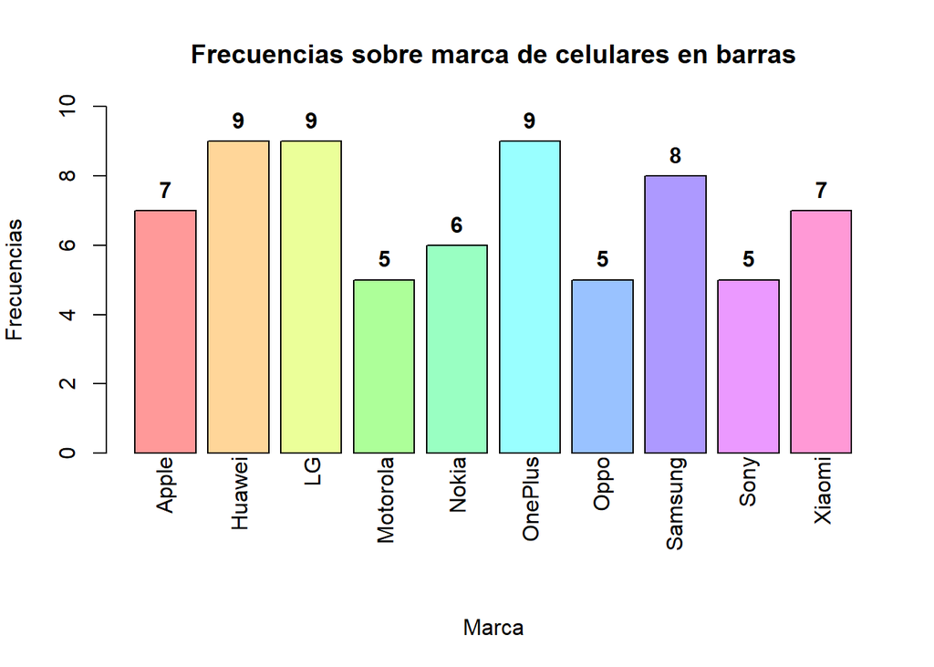

```r
par(mar=c(8,4,4,2))
gb<-barplot(contador, col=rainbow(10,0.4),
        main="Frecuencias sobre marca de celulares en barras",
        xlab="",
        names.arg="",
        ylab="Frecuencias",
        ylim=c(0,10),
        )
title(xlab="Marca",line=6)

#Etiquetas rotadas
text(x=gb,
     y=par("usr")[3]-0.1,
     labels=names(contador),
     srt=90,
     adj=1,
     xpd=TRUE,
     cex=1)

# Agregar valores encima de cada barra
text(x=gb,
     y=contador,
     labels=contador,
     pos=3,
     cex=1,
     font=2)
```

#### Gráfica de porcentajes

Generamos la gráfica de porcentajes.

```r
par(mar=c(8,4,4,2))
tabla <- table(marca); (tabla)
```

```
## marca
##    Apple   Huawei       LG Motorola    Nokia  OnePlus     Oppo  Samsung
##        7        9        9        5        6        9        5        8
##     Sony   Xiaomi
##        5        7
```

```r
porcentajes <-  round(prop.table(tabla)* 100, 1); (porcentajes)
```

```
## marca
##    Apple   Huawei       LG Motorola    Nokia  OnePlus     Oppo  Samsung
##     10.0     12.9     12.9      7.1      8.6     12.9      7.1     11.4
##     Sony   Xiaomi
##      7.1     10.0
```

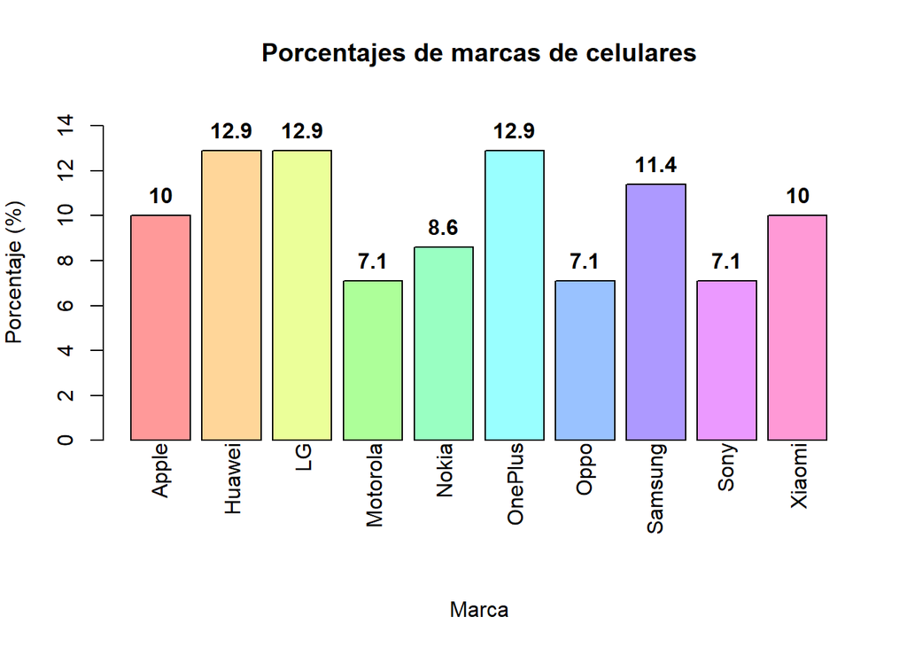

```r
gp<- barplot(porcentajes, col = rainbow(length(tabla),0.4),
    main = "Porcentajes de marcas de celulares",
    xlab = "",
    names.arg="",
    ylab="Porcentaje (%)",
    ylim=c(0,15),
        )

title(xlab="Marca",line=6)

#Etiquetas rotadas
text(x=gb,
     y=par("usr")[3]-0.1,
     labels=names(contador),
     srt=90,
     adj=1,
     xpd=TRUE,
     cex=1)

# Agregar valores encima de cada barra
text(x=gp,
     y=porcentajes,
     labels=porcentajes,
     pos=3,
     cex=1,
     font=2)
```

#### Gráfica de pasteles

Generamos la gráfica de pasteles.

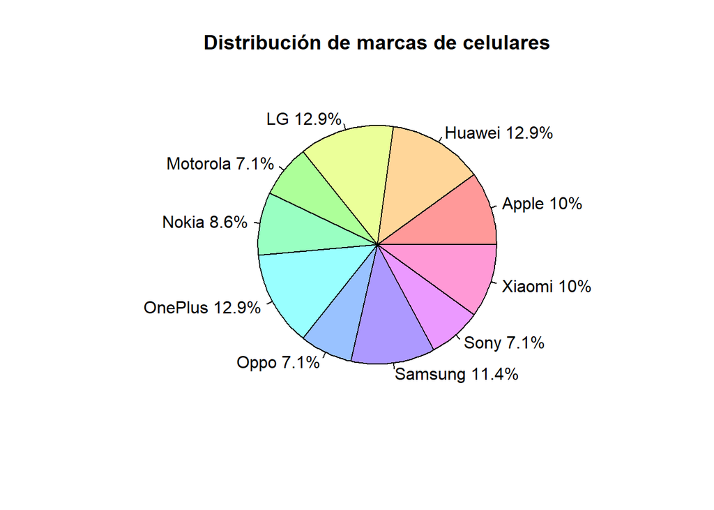

```r
pie(tabla,
    main = "Distribución de marcas de celulares",
    col = rainbow(length(tabla),0.4),
    labels = paste0(names(tabla)," ",porcentajes, "%"))
```

```r
#---- Fin ----
```

## Ejercicio 6.5 Estado civil

### Datos

```r
estado <- c("Viudo", "Viudo", "Union", "libre", "Soltero", "Viudo", "Union libre", "Divorciado",
"Casado", "Union libre", "Viudo", "Viudo", "Soltero", "Divorciado", "Divorciado", "Divorciado",
"Union libre", "Casado", "Union libre", "Casado", "Soltero", "Viudo", "Casado", "Casado", "Divorciado",
"Union libre", "Soltero", "Divorciado", "Divorciado", "Casado", "Union libre", "Soltero",
"Viudo", "Viudo", "Soltero", "Divorciado", "Viudo", "Viudo", "Soltero", "Union libre", "Divorciado")
```

### Procesamiento de datos

Primero obtenemos un resumen de los datos generados

```r
summary(estado)
```

```
##    Length     Class      Mode
##        41 character character
```

Al ser variables de tipo Nominal no se pueden ordenar ni se pueden obtener los deciles ni cuartiles.

### Frecuencias

Obtenemos las frecuencias de los datos.

```r
(estado) #Datos
```

```
##  [1] "Viudo"       "Viudo"       "Union"       "libre"       "Soltero"
##  [6] "Viudo"       "Union libre" "Divorciado"  "Casado"      "Union libre"
## [11] "Viudo"       "Viudo"       "Soltero"     "Divorciado"  "Divorciado"
## [16] "Divorciado"  "Union libre" "Casado"      "Union libre" "Casado"
## [21] "Soltero"     "Viudo"       "Casado"      "Casado"      "Divorciado"
## [26] "Union libre" "Soltero"     "Divorciado"  "Divorciado"  "Casado"
## [31] "Union libre" "Soltero"     "Viudo"       "Viudo"       "Soltero"
## [36] "Divorciado"  "Viudo"       "Viudo"       "Soltero"     "Union libre"
## [41] "Divorciado"
```

```r
sort(estado) #Datos ordenados por clase
```

```
##  [1] "Casado"      "Casado"      "Casado"      "Casado"      "Casado"
##  [6] "Casado"      "Divorciado"  "Divorciado"  "Divorciado"  "Divorciado"
## [11] "Divorciado"  "Divorciado"  "Divorciado"  "Divorciado"  "Divorciado"
## [16] "libre"       "Soltero"     "Soltero"     "Soltero"     "Soltero"
## [21] "Soltero"     "Soltero"     "Soltero"     "Union"       "Union libre"
## [26] "Union libre" "Union libre" "Union libre" "Union libre" "Union libre"
## [31] "Union libre" "Viudo"       "Viudo"       "Viudo"       "Viudo"
## [36] "Viudo"       "Viudo"       "Viudo"       "Viudo"       "Viudo"
## [41] "Viudo"
```

```r
contador <- table(estado) #Frecuencia de los datos
(contador)
```

```
## estado
##      Casado  Divorciado       libre     Soltero       Union Union libre
##           6           9           1           7           1           7
##       Viudo
##          10
```

### Proporciones

Obtenemos las proporciones.

```r
prop.table(table(estado)) #Proporciones
```

```
## estado
##      Casado  Divorciado       libre     Soltero       Union Union libre
##  0.14634146  0.21951220  0.02439024  0.17073171  0.02439024  0.17073171
##       Viudo
##  0.24390244
```

### Medidas de tendencia central

Obtenemos la moda

```r
# Función para detectar modalidad
max_frecuencia <- max(contador)
modas <- names(contador)[contador == max_frecuencia]

# Identificar e imprimir resultado
if(length(modas) == 1) {
  cat("UNIMODAL - Moda:", modas)
} else if(length(modas) == 2) {
  cat("BIMODAL - Modas:", paste(modas, collapse = " y "))
} else {
  cat("Hay más de dos clases con mayor frecuencia por lo tanto no hay moda")
}
```

```
## UNIMODAL - Moda: Viudo
```

### Gráficos

Comenzamos a graficar.

#### Gráfica con el comando *barplot*

Generemos la gráfica de barras.

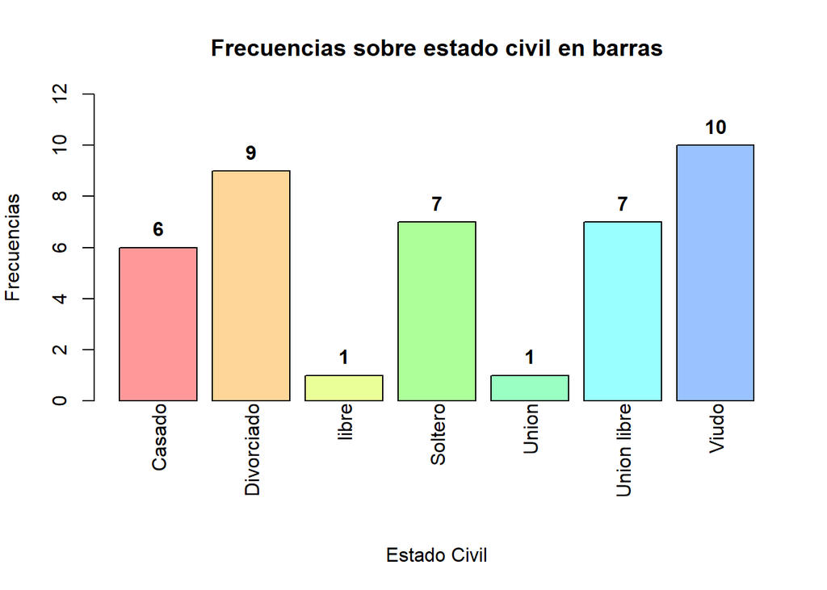

```r
par(mar=c(8,4,4,2))
gb<-barplot(contador, col=rainbow(10,0.4),
        main="Frecuencias sobre estado civil en barras",
        xlab="",
        names.arg="",
        ylab="Frecuencias",
        ylim=c(0,12),
        )
title(xlab="Estado Civil",line=6)

#Etiquetas rotadas
text(x=gb,
     y=par("usr")[3]-0.1,
     labels=names(contador),
     srt=90,
     adj=1,
     xpd=TRUE,
     cex=1)

# Agregar valores encima de cada barra
text(x=gb,
     y=contador,
     labels=contador,
     pos=3,
     cex=1,
     font=2)
```

#### Gráfica de porcentajes

Generamos la gráfica de porcentajes.

```r
par(mar=c(8,4,4,2))
tabla <- table(estado); (tabla)
```

```
## estado
##      Casado  Divorciado       libre     Soltero       Union Union libre
##           6           9           1           7           1           7
##       Viudo
##          10
```

```r
porcentajes <-  round(prop.table(tabla)* 100, 1); (porcentajes)
```

```
## estado
##      Casado  Divorciado       libre     Soltero       Union Union libre
##        14.6        22.0         2.4        17.1         2.4        17.1
##       Viudo
##        24.4
```

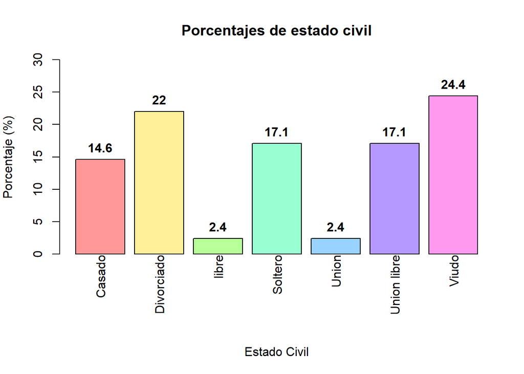

```r
gp<- barplot(porcentajes, col = rainbow(length(tabla),0.4),
    main = "Porcentajes de estado civil",
    xlab = "",
    names.arg="",
    ylab="Porcentaje (%)",
    ylim=c(0,30),
        )

title(xlab="Estado Civil",line=6)

#Etiquetas rotadas
text(x=gb,
     y=par("usr")[3]-0.1,
     labels=names(contador),
     srt=90,
     adj=1,
     xpd=TRUE,
     cex=1)

# Agregar valores encima de cada barra
text(x=gp,
     y=porcentajes,
     labels=porcentajes,
     pos=3,
     cex=1,
     font=2)
```

#### Gráfica de pasteles

Generamos la gráfica de pasteles.

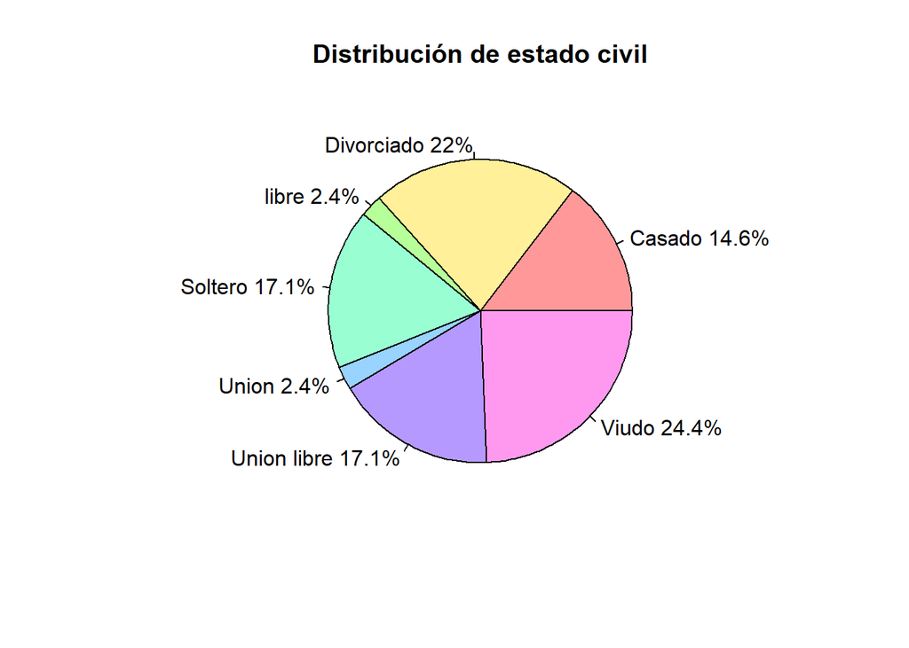

```r
pie(tabla,
    main = "Distribución de estado civil",
    col = rainbow(length(tabla),0.4),
    labels = paste0(names(tabla)," ",porcentajes, "%"))
```

```r
#---- Fin ----
```

# Ejercicio 7: Variables Ordinales

## Ejercicio 7.1 Nivel educativo

### Datos

```r
nivel_educativo <- c("posdoctorado", "preparatoria", "preparatoria", "doctorado", "primaria", "doctorado", "preparatoria", "secundaria", "preparatoria", "preparatoria", "primaria", "doctorado",
"secundaria", "secundaria", "secundaria", "licenciatura", "doctorado", "primaria", "maestria", "posdoctorado", "maestria", "preparatoria", "posdoctorado", "doctorado", "preparatoria", "doctorado",
"maestria", "primaria", "licenciatura", "secundaria", "maestria", "posdoctorado", "doctorado", "licenciatura", "doctorado", "posdoctorado", "maestria", "primaria", "secundaria", "preparatoria")
```

### Procesamiento de datos

Primero obtenemos un resumen de los datos generados

```r
summary(nivel_educativo)
```

```
##    Length     Class      Mode
##        40 character character
```

Al ser variables de tipo Ordinal se pueden ordenar bajo un discriminante elegido, en este caso, de menor a mayor preparación académica.

### Frecuencias

Obtenemos las frecuencias de los datos.

```r
(nivel_educativo) #Datos
```

```
##  [1] "posdoctorado" "preparatoria" "preparatoria" "doctorado"    "primaria"
##  [6] "doctorado"    "preparatoria" "secundaria"   "preparatoria" "preparatoria"
## [11] "primaria"     "doctorado"    "secundaria"   "secundaria"   "secundaria"
## [16] "licenciatura" "doctorado"    "primaria"     "maestria"     "posdoctorado"
## [21] "maestria"     "preparatoria" "posdoctorado" "doctorado"    "preparatoria"
## [26] "doctorado"    "maestria"     "primaria"     "licenciatura" "secundaria"
## [31] "maestria"     "posdoctorado" "doctorado"    "licenciatura" "doctorado"
## [36] "posdoctorado" "maestria"     "primaria"     "secundaria"   "preparatoria"
```

```r
sort(nivel_educativo) #Datos ordenados por clase
```

```
##  [1] "doctorado"    "doctorado"    "doctorado"    "doctorado"    "doctorado"
##  [6] "doctorado"    "doctorado"    "doctorado"    "licenciatura" "licenciatura"
## [11] "licenciatura" "maestria"     "maestria"     "maestria"     "maestria"
## [16] "maestria"     "posdoctorado" "posdoctorado" "posdoctorado" "posdoctorado"
## [21] "posdoctorado" "preparatoria" "preparatoria" "preparatoria" "preparatoria"
## [26] "preparatoria" "preparatoria" "preparatoria" "preparatoria" "primaria"
## [31] "primaria"     "primaria"     "primaria"     "primaria"     "secundaria"
## [36] "secundaria"   "secundaria"   "secundaria"   "secundaria"   "secundaria"
```

```r
contador <- table(nivel_educativo) #Frecuencia de los datos
(contador)
```

```
## nivel_educativo
##    doctorado licenciatura     maestria posdoctorado preparatoria     primaria
##            8            3            5            5            8            5
##   secundaria
##            6
```

### Proporciones

Obtenemos las proporciones.

```r
prop.table(table(nivel_educativo)) #Proporciones
```

```
## nivel_educativo
##    doctorado licenciatura     maestria posdoctorado preparatoria     primaria
##        0.200        0.075        0.125        0.125        0.200        0.125
##   secundaria
##        0.150
```

### Medidas de tendencia central

#### Moda

Obtenemos la moda

```r
# Función para detectar modalidad
max_frecuencia <- max(contador)
modas <- names(contador)[contador == max_frecuencia]

# Identificar e imprimir resultado
if(length(modas) == 1) {
  cat("UNIMODAL - Moda:", modas)
} else if(length(modas) == 2) {
  cat("BIMODAL - Modas:", paste(modas, collapse = " y "))
} else {
  cat("Hay más de dos clases con mayor frecuencia por lo tanto no hay moda")
}
```

```
## BIMODAL - Modas: doctorado y preparatoria
```

#### Mediana

Obtenemos la mediana

```r
mediana_academica <- function(nivel_educativo) {
  niveles <- c("primaria", "secundaria", "preparatoria", "licenciatura",
               "maestria", "doctorado", "posdoctorado") #Con esto ordenamos nuestras clases de menor a mayor nivel académico

  # Convertir a numérico, ordenar y reconvertir a texto
  numerico_ord <- sort(sapply(nivel_educativo, function(x) which(niveles == x)))
  (numerico_ord)
  texto_ord <- niveles[numerico_ord]
  cat("Datos ordenados:   ", paste(texto_ord, collapse = ", "), "\n")

  # Calcular mediana
  mediana<- median(numerico_ord)
  resultado <- niveles[round(mediana)]

  cat("La mediana es:", resultado, "\n")
  return(resultado)
}

resultado <- mediana_academica(nivel_educativo)
```

[output not shown]

#### Media

A pesar de tener datos que se pueden ordenar, no se puede tener una media debido a que no tenemos datos numéricos con los cuales calcular.

### Medidas de localización

#### Cuartiles

```r
niveles <- c("primaria", "secundaria", "preparatoria", "licenciatura",
             "maestria", "doctorado", "posdoctorado")

numerico <- sapply(nivel_educativo, function(x) which(niveles == x))
numerico_ord <- sort(numerico)

q1 <- niveles[round(quantile(numerico_ord, 0.25))]
(q1)
```

```
## [1] "secundaria"
```

```r
q2 <- niveles[round(quantile(numerico_ord, 0.50))]
(q2)
```

```
## [1] "licenciatura"
```

```r
q3 <- niveles[round(quantile(numerico_ord, 0.75))]
(q3)
```

```
## [1] "doctorado"
```

```r
mi_min <- min(nivel_educativo);
(mi_min)
```

```
## [1] "doctorado"
```

```r
mi_max <- max(nivel_educativo);
(mi_max)
```

```
## [1] "secundaria"
```

### Diagrama de caja y brazos

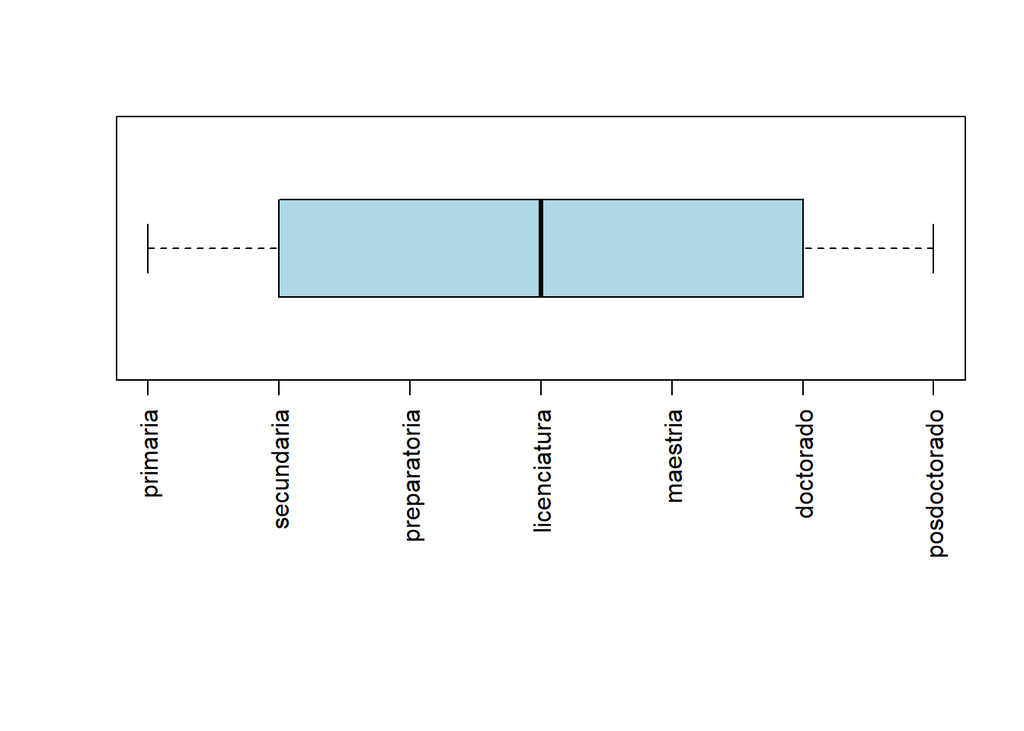

```r
par(mar=c(12,4,4,2))
boxplot(numerico_ord, horizontal = TRUE, col = "lightblue", xaxt = "n")
axis(1, at = 1:7, labels = niveles, las=2)
```

### Gráficos

Comenzamos a graficar.

#### Gráfica con el comando *barplot*

Generemos la gráfica de barras.

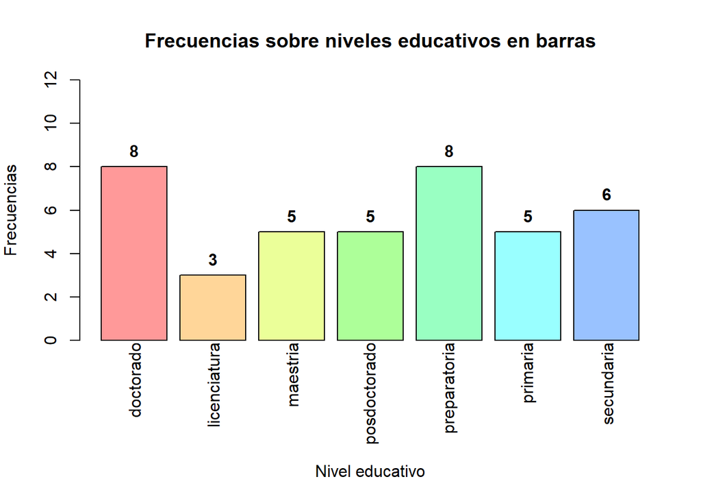

```r
par(mar=c(8,4,4,2))
gb<-barplot(contador, col=rainbow(10,0.4),
        main="Frecuencias sobre niveles educativos en barras",
        xlab="",
        names.arg="",
        ylab="Frecuencias",
        ylim=c(0,12),
        )
title(xlab="Nivel educativo",line=6)

#Etiquetas rotadas
text(x=gb,
     y=par("usr")[3]-0.1,
     labels=names(contador),
     srt=90,
     adj=1,
     xpd=TRUE,
     cex=1)

# Agregar valores encima de cada barra
text(x=gb,
     y=contador,
     labels=contador,
     pos=3,
     cex=1,
     font=2)
```

#### Gráfica de porcentajes

Generamos la gráfica de porcentajes.

```r
par(mar=c(8,4,4,2))
tabla <- table(nivel_educativo); (tabla)
```

```
## nivel_educativo
##    doctorado licenciatura     maestria posdoctorado preparatoria     primaria
##            8            3            5            5            8            5
##   secundaria
##            6
```

```r
porcentajes <-  round(prop.table(tabla)* 100, 1); (porcentajes)
```

```
## nivel_educativo
##    doctorado licenciatura     maestria posdoctorado preparatoria     primaria
##         20.0          7.5         12.5         12.5         20.0         12.5
##   secundaria
##         15.0
```

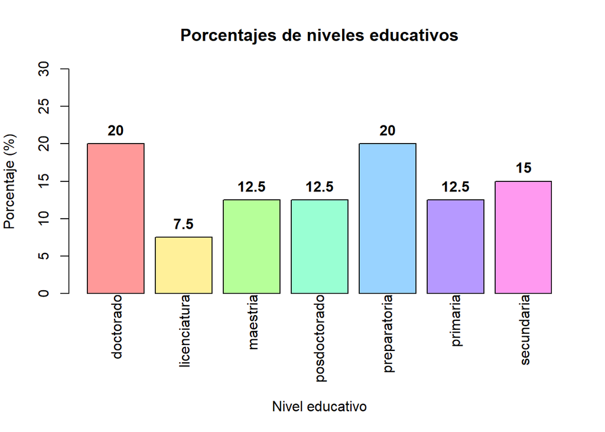

```r
gp<- barplot(porcentajes, col = rainbow(length(tabla),0.4),
    main = "Porcentajes de niveles educativos",
    xlab = "",
    names.arg="",
    ylab="Porcentaje (%)",
    ylim=c(0,30),
        )

title(xlab="Nivel educativo",line=6)

#Etiquetas rotadas
text(x=gb,
     y=par("usr")[3]-0.1,
     labels=names(contador),
     srt=90,
     adj=1,
     xpd=TRUE,
     cex=1)

# Agregar valores encima de cada barra
text(x=gp,
     y=porcentajes,
     labels=porcentajes,
     pos=3,
     cex=1,
     font=2)
```

#### Gráfica de pasteles

Generamos la gráfica de pasteles.

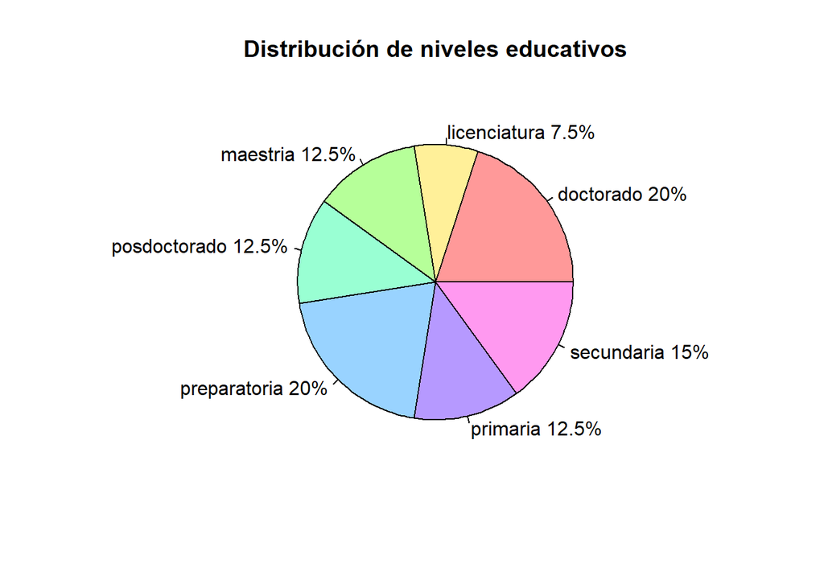

```r
pie(tabla,
    main = "Distribución de niveles educativos",
    col = rainbow(length(tabla),0.4),
    labels = paste0(names(tabla)," ",porcentajes, "%"))
```

#### Gráfica de ovija

Generamos la gráfica de ojiva

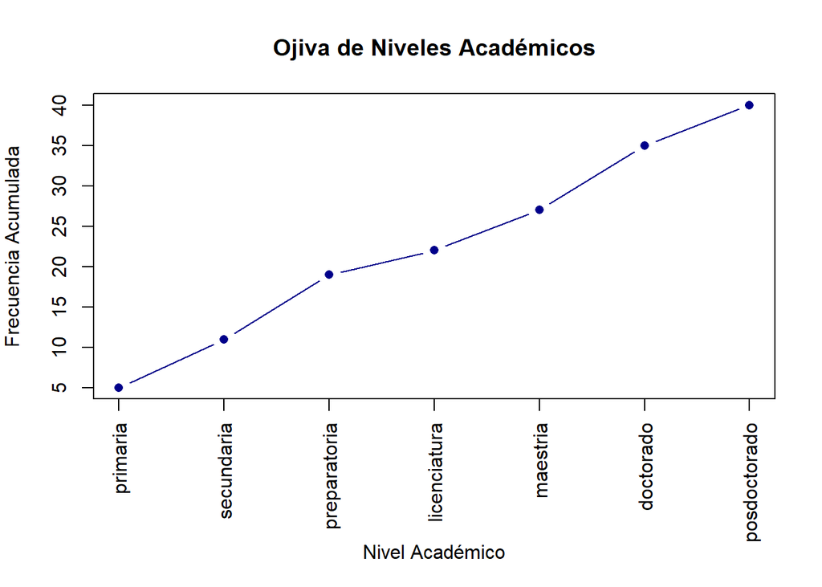

```r
par(mar=c(8,4,4,2))
frec_acum <- cumsum(table(factor(nivel_educativo, levels = niveles)))
plot(frec_acum, type = "b", pch = 16, col = "darkblue",
     main = "Ojiva de Niveles Académicos",
     xlab = "",
     names.arg="",
     ylab = "Frecuencia Acumulada",
     xaxt = "n")
title(xlab="Nivel Académico",line=6)
axis(1, at = 1:7, labels = niveles, las = 2)  # el comando las = 2 hace las etiquetas de las clases verticales
```

```r
#---- Fin ----
```

### Datos

```r
nivel_satisfaccion <- c("satisfecho", "muy satisfecho", "muy insatisfecho", "neutral", "muy satisfecho", "muy insatisfecho", "muy satisfecho", "insatisfecho", "muy insatisfecho", "insatisfecho", "muy satisfecho", "insatisfecho", "muy satisfecho", "muy satisfecho", "mas o menos insatisfecho", "insatisfecho", "satisfecho", "muy satisfecho", "neutral", "mas o menos insatisfecho", "muy insatisfecho", "mas o menos satisfecho", "insatisfecho", "neutral", "mas o menos satisfecho", "satisfecho", "mas o menos satisfecho", "satisfecho", "neutral", "satisfecho", "muy insatisfecho", "muy insatisfecho", "neutral", "satisfecho", "insatisfecho", "mas o menos satisfecho", "mas o menos insatisfecho", "muy insatisfecho", "neutral", "neutral", "satisfecho", "neutral", "insatisfecho", "mas o menos insatisfecho", "mas o menos insatisfecho", "insatisfecho", "mas o menos satisfecho", "satisfecho", "neutral", "insatisfecho", "insatisfecho", "muy insatisfecho", "muy satisfecho", "mas o menos satisfecho", "mas o menos satisfecho")
```

### Procesamiento de datos

Primero obtenemos un resumen de los datos generados

```r
summary(nivel_satisfaccion)
```

```
##    Length     Class      Mode
##        55 character character
```

Al ser variables de tipo Ordinal se pueden ordenar bajo un discriminante elegido, en este caso, de menor a mayor nivel de satisfacción.

### Frecuencias

Obtenemos las frecuencias de los datos.

```r
(nivel_satisfaccion) #Datos
```

```
##  [1] "satisfecho"               "muy satisfecho"
##  [3] "muy insatisfecho"         "neutral"
##  [5] "muy satisfecho"           "muy insatisfecho"
##  [7] "muy satisfecho"           "insatisfecho"
##  [9] "muy insatisfecho"         "insatisfecho"
## [11] "muy satisfecho"           "insatisfecho"
## [13] "muy satisfecho"           "muy satisfecho"
## [15] "mas o menos insatisfecho" "insatisfecho"
## [17] "satisfecho"               "muy satisfecho"
## [19] "neutral"                  "mas o menos insatisfecho"
## [21] "muy insatisfecho"         "mas o menos satisfecho"
## [23] "insatisfecho"             "neutral"
## [25] "mas o menos satisfecho"   "satisfecho"
## [27] "mas o menos satisfecho"   "satisfecho"
## [29] "neutral"                  "satisfecho"
## [31] "muy insatisfecho"         "muy insatisfecho"
## [33] "neutral"                  "satisfecho"
## [35] "insatisfecho"             "mas o menos satisfecho"
## [37] "mas o menos insatisfecho" "muy insatisfecho"
## [39] "neutral"                  "neutral"
## [41] "satisfecho"               "neutral"
## [43] "insatisfecho"             "mas o menos insatisfecho"
## [45] "mas o menos insatisfecho" "insatisfecho"
## [47] "mas o menos satisfecho"   "satisfecho"
## [49] "neutral"                  "insatisfecho"
## [51] "insatisfecho"             "muy insatisfecho"
## [53] "muy satisfecho"           "mas o menos satisfecho"
## [55] "mas o menos satisfecho"
```

```r
sort(nivel_satisfaccion) #Datos ordenados por clase
```

```
##  [1] "insatisfecho"             "insatisfecho"
##  [3] "insatisfecho"             "insatisfecho"
##  [5] "insatisfecho"             "insatisfecho"
##  [7] "insatisfecho"             "insatisfecho"
##  [9] "insatisfecho"             "insatisfecho"
## [11] "mas o menos insatisfecho" "mas o menos insatisfecho"
## [13] "mas o menos insatisfecho" "mas o menos insatisfecho"
## [15] "mas o menos insatisfecho" "mas o menos satisfecho"
## [17] "mas o menos satisfecho"   "mas o menos satisfecho"
## [19] "mas o menos satisfecho"   "mas o menos satisfecho"
## [21] "mas o menos satisfecho"   "mas o menos satisfecho"
## [23] "muy insatisfecho"         "muy insatisfecho"
## [25] "muy insatisfecho"         "muy insatisfecho"
## [27] "muy insatisfecho"         "muy insatisfecho"
## [29] "muy insatisfecho"         "muy insatisfecho"
## [31] "muy satisfecho"           "muy satisfecho"
## [33] "muy satisfecho"           "muy satisfecho"
## [35] "muy satisfecho"           "muy satisfecho"
## [37] "muy satisfecho"           "muy satisfecho"
## [39] "neutral"                  "neutral"
## [41] "neutral"                  "neutral"
## [43] "neutral"                  "neutral"
## [45] "neutral"                  "neutral"
## [47] "neutral"                  "satisfecho"
## [49] "satisfecho"               "satisfecho"
## [51] "satisfecho"               "satisfecho"
## [53] "satisfecho"               "satisfecho"
## [55] "satisfecho"
```

```r
contador <- table(nivel_satisfaccion) #Frecuencia de los datos
(contador)
```

```
## nivel_satisfaccion
##             insatisfecho mas o menos insatisfecho   mas o menos satisfecho
##                       10                        5                        7
##         muy insatisfecho           muy satisfecho                  neutral
##                        8                        8                        9
##               satisfecho
##                        8
```

### Proporciones

Obtenemos las proporciones.

```r
prop.table(table(nivel_satisfaccion)) #Proporciones
```

```
## nivel_satisfaccion
##             insatisfecho mas o menos insatisfecho   mas o menos satisfecho
##               0.18181818               0.09090909               0.12727273
##         muy insatisfecho           muy satisfecho                  neutral
##               0.14545455               0.14545455               0.16363636
##               satisfecho
##               0.14545455
```

### Medidas de tendencia central

#### Moda

Obtenemos la moda

```r
# Función para detectar modalidad
max_frecuencia <- max(contador)
modas <- names(contador)[contador == max_frecuencia]

# Identificar e imprimir resultado
if(length(modas) == 1) {
  cat("UNIMODAL - Moda:", modas)
} else if(length(modas) == 2) {
  cat("BIMODAL - Modas:", paste(modas, collapse = " y "))
} else {
  cat("Hay más de dos clases con mayor frecuencia por lo tanto no hay moda")
}
```

```
## UNIMODAL - Moda: insatisfecho
```

#### Mediana

Obtenemos la mediana

```r
mediana_satisfaccion <- function(nivel_satisfaccion) {
  niveles <- c("muy insatisfecho", "insatisfecho", "mas o menos insatisfecho", "neutral",
               "mas o menos satisfecho", "satisfecho", "muy satisfecho") #Con esto ordenamos nuestras clases de menor a mayor nivel de satisfacción

  # Convertir a numérico, ordenar y reconvertir a texto
  numerico_ord <- sort(sapply(nivel_satisfaccion, function(x) which(niveles == x)))
  (numerico_ord)
  texto_ord <- niveles[numerico_ord]
  cat("Datos ordenados:   ", paste(texto_ord, collapse = ", "), "\n")

  # Calcular mediana
  mediana<- median(numerico_ord)
  resultado <- niveles[round(mediana)]

  cat("La mediana es:", resultado, "\n")
  return(resultado)
}

resultado <- mediana_satisfaccion(nivel_satisfaccion)
```

```
## Datos ordenados:    muy insatisfecho, muy insatisfecho, muy insatisfecho, muy insatisfecho, muy insatisfecho, muy insatisfecho, muy insatisfecho, muy insatisfecho, insatisfecho, insatisfecho, insatisfecho, insatisfecho, insatisfecho, insatisfecho, insatisfecho, insatisfecho, insatisfecho, insatis…
## La mediana es: neutral
```

#### Media

A pesar de tener datos que se pueden ordenar, no se puede tener una media debido a que no tenemos datos numéricos con los cuales calcular.

### Medidas de localización

#### Cuartiles

```r
niveles <- c("muy insatisfecho", "insatisfecho", "mas o menos insatisfecho", "neutral",
               "mas o menos satisfecho", "satisfecho", "muy satisfecho")

numerico <- sapply(nivel_satisfaccion, function(x) which(niveles == x))
numerico_ord <- sort(numerico)

q1 <- niveles[round(quantile(numerico_ord, 0.25))]
(q1)
```

```
## [1] "insatisfecho"
```

```r
q2 <- niveles[round(quantile(numerico_ord, 0.50))]
(q2)
```

```
## [1] "neutral"
```

```r
q3 <- niveles[round(quantile(numerico_ord, 0.75))]
(q3)
```

```
## [1] "satisfecho"
```

Calculemos el valor máximo y el valor mínimo para los datos

```r
mi_min <- min(nivel_satisfaccion);
(mi_min)
```

```
## [1] "insatisfecho"
```

```r
mi_max <- max(nivel_satisfaccion);
(mi_max)
```

```
## [1] "satisfecho"
```

### Diagrama de caja y brazos

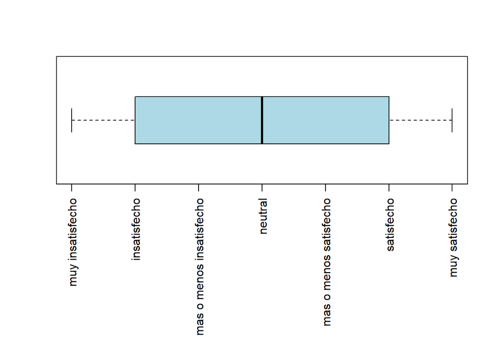

```r
par(mar=c(12,4,4,2))
boxplot(numerico_ord, horizontal = TRUE, col = "lightblue", xaxt = "n")
axis(1, at = 1:7, labels = niveles, las=2)
```

### Gráficos

Comenzamos a graficar.

#### Gráfica con el comando *barplot*

Generemos la gráfica de barras.

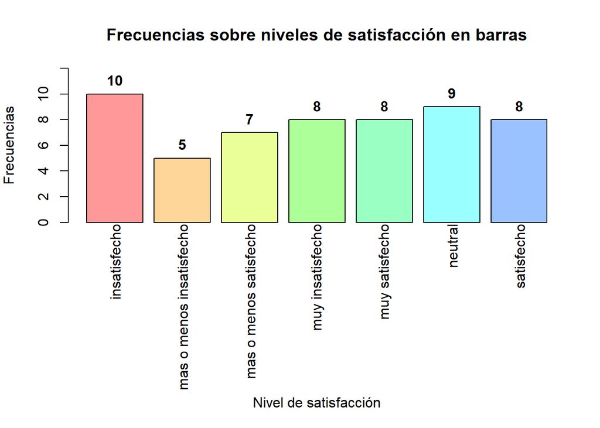

```r
par(mar=c(12,4,4,2))
gb<-barplot(contador, col=rainbow(10,0.4),
        main="Frecuencias sobre niveles de satisfacción en barras",
        xlab="",
        names.arg="",
        ylab="Frecuencias",
        ylim=c(0,12),
        )
title(xlab="Nivel de satisfacción",line=10)

#Etiquetas rotadas
text(x=gb,
     y=par("usr")[3]-0.1,
     labels=names(contador),
     srt=90,
     adj=1,
     xpd=TRUE,
     cex=1)

# Agregar valores encima de cada barra
text(x=gb,
     y=contador,
     labels=contador,
     pos=3,
     cex=1,
     font=2)
```

#### Gráfica de porcentajes

Generamos la gráfica de porcentajes.

```r
par(mar=c(12,4,4,2))
tabla <- table(nivel_satisfaccion); (tabla)
```

```
## nivel_satisfaccion
##             insatisfecho mas o menos insatisfecho   mas o menos satisfecho
##                       10                        5                        7
##         muy insatisfecho           muy satisfecho                  neutral
##                        8                        8                        9
##               satisfecho
##                        8
```

```r
porcentajes <-  round(prop.table(tabla)* 100, 1); (porcentajes)
```

```
## nivel_satisfaccion
##             insatisfecho mas o menos insatisfecho   mas o menos satisfecho
##                     18.2                      9.1                     12.7
##         muy insatisfecho           muy satisfecho                  neutral
##                     14.5                     14.5                     16.4
##               satisfecho
##                     14.5
```

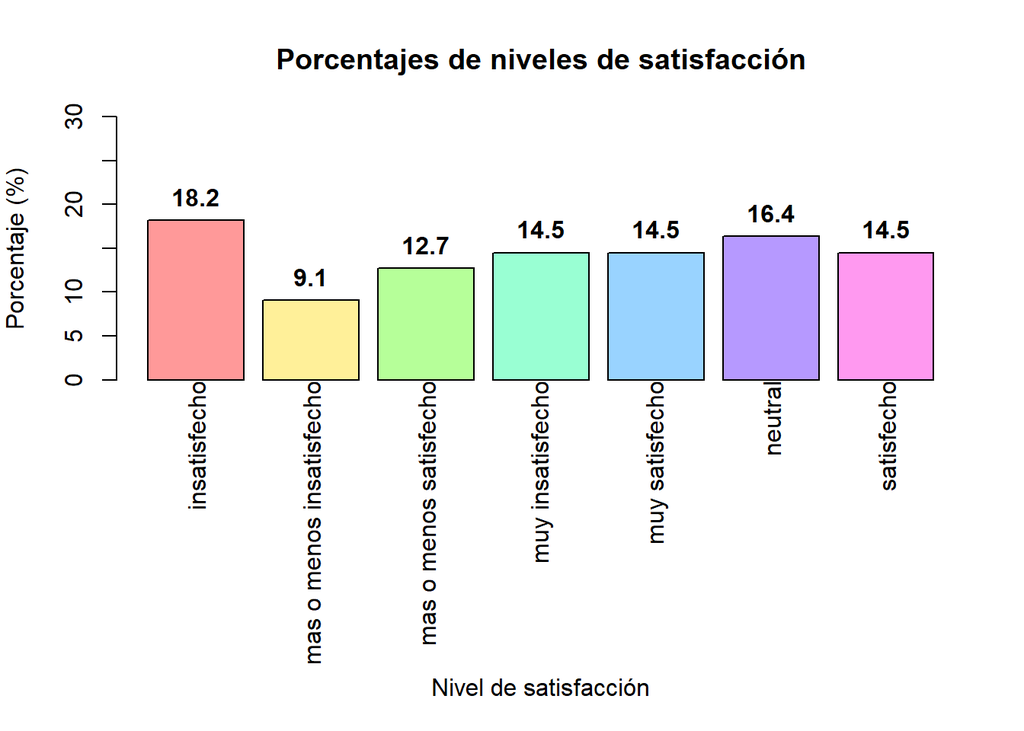

```r
gp<- barplot(porcentajes, col = rainbow(length(tabla),0.4),
    main = "Porcentajes de niveles de satisfacción",
    xlab = "",
    names.arg="",
    ylab="Porcentaje (%)",
    ylim=c(0,30),
        )

title(xlab="Nivel de satisfacción",line=10)

#Etiquetas rotadas
text(x=gb,
     y=par("usr")[3]-0.1,
     labels=names(contador),
     srt=90,
     adj=1,
     xpd=TRUE,
     cex=1)

# Agregar valores encima de cada barra
text(x=gp,
     y=porcentajes,
     labels=porcentajes,
     pos=3,
     cex=1,
     font=2)
```

#### Gráfica de pasteles

Generamos la gráfica de pasteles.

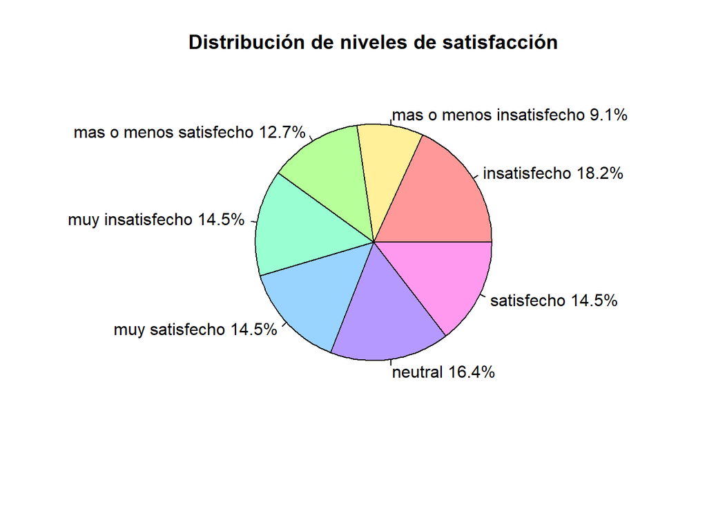

```r
pie(tabla,
    main = "Distribución de niveles de satisfacción",
    col = rainbow(length(tabla),0.4),
    labels = paste0(names(tabla)," ",porcentajes, "%"))
```

#### Gráfica de ovija

Generamos la gráfica de ojiva

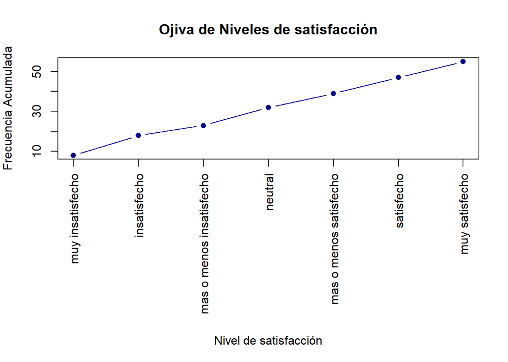

```r
par(mar=c(14,4,4,2))
frec_acum <- cumsum(table(factor(nivel_satisfaccion, levels = niveles)))
plot(frec_acum, type = "b", pch = 16, col = "darkblue",
     main = "Ojiva de Niveles de satisfacción",
     xlab = "",
     names.arg="",
     ylab = "Frecuencia Acumulada",
     xaxt = "n")
title(xlab="Nivel de satisfacción",line=12)
axis(1, at = 1:7, labels = niveles, las = 2)  # el comando las = 2 hace las etiquetas de las clases verticales
```

```r
#---- Fin ----
```

## Ejercicio 7.3 Grado de dolor

### Datos

```r
grado_dolor <- c("severo", "leve", "leve", "severo", "leve", "leve", "leve", "moderado", "moderado",
"moderado", "moderado", "severo", "severo", "moderado", "leve", "severo", "leve", "severo", "severo",
"severo", "leve", "moderado", "severo", "severo", "leve", "leve", "leve", "severo", "severo", "leve")
```

### Procesamiento de datos

Primero obtenemos un resumen de los datos generados

```r
summary(grado_dolor)
```

```
##    Length     Class      Mode
##        30 character character
```

### Frecuencias

Obtenemos las frecuencias de los datos.

```r
(grado_dolor) #Datos
```

```
##  [1] "severo"   "leve"     "leve"     "severo"   "leve"     "leve"
##  [7] "leve"     "moderado" "moderado" "moderado" "moderado" "severo"
## [13] "severo"   "moderado" "leve"     "severo"   "leve"     "severo"
## [19] "severo"   "severo"   "leve"     "moderado" "severo"   "severo"
## [25] "leve"     "leve"     "leve"     "severo"   "severo"   "leve"
```

```r
sort(grado_dolor) #Datos ordenados por clase
```

```
##  [1] "leve"     "leve"     "leve"     "leve"     "leve"     "leve"
##  [7] "leve"     "leve"     "leve"     "leve"     "leve"     "leve"
## [13] "moderado" "moderado" "moderado" "moderado" "moderado" "moderado"
## [19] "severo"   "severo"   "severo"   "severo"   "severo"   "severo"
## [25] "severo"   "severo"   "severo"   "severo"   "severo"   "severo"
```

```r
contador <- table(grado_dolor) #Frecuencia de los datos
(contador)
```

```
## grado_dolor
##     leve moderado   severo
##       12        6       12
```

### Proporciones

Obtenemos las proporciones.

```r
prop.table(table(grado_dolor)) #Proporciones
```

```
## grado_dolor
##     leve moderado   severo
##      0.4      0.2      0.4
```

### Medidas de tendencia central

#### Moda

Obtenemos la moda

```r
# Función para detectar modalidad
max_frecuencia <- max(contador)
modas <- names(contador)[contador == max_frecuencia]

# Identificar e imprimir resultado
if(length(modas) == 1) {
  cat("UNIMODAL - Moda:", modas)
} else if(length(modas) == 2) {
  cat("BIMODAL - Modas:", paste(modas, collapse = " y "))
} else {
  cat("Hay más de dos clases con mayor frecuencia por lo tanto no hay moda")
}
```

```
## BIMODAL - Modas: leve y severo
```

#### Mediana

Obtenemos la mediana

```r
mediana_dolor <- function(grado_dolor) {
  niveles <- c("leve", "moderado", "severo") #Con esto ordenamos nuestras clases de menor a mayor grado de dolor

  # Convertir a numérico, ordenar y reconvertir a texto
  numerico_ord <- sort(sapply(grado_dolor, function(x) which(niveles == x)))
  (numerico_ord)
  texto_ord <- niveles[numerico_ord]
  cat("Datos ordenados:   ", paste(texto_ord, collapse = ", "), "\n")

  # Calcular mediana
  mediana<- median(numerico_ord)
  resultado <- niveles[round(mediana)]

  cat("La mediana es:", resultado, "\n")
  return(resultado)
}

resultado <- mediana_dolor(grado_dolor)
```

```
## Datos ordenados:    leve, leve, leve, leve, leve, leve, leve, leve, leve, leve, leve, leve, moderado, moderado, moderado, moderado, moderado, moderado, severo, severo, severo, severo, severo, severo, severo, severo, severo, severo, severo, severo
## La mediana es: moderado
```

#### Media

A pesar de tener datos que se pueden ordenar, no se puede tener una media debido a que no tenemos datos numéricos con los cuales calcular.

### Medidas de localización

#### Cuartiles

```r
niveles <- c("leve", "moderado", "severo")

numerico <- sapply(grado_dolor, function(x) which(niveles == x))
numerico_ord <- sort(numerico)

q1 <- niveles[round(quantile(numerico_ord, 0.25))]
(q1)
```

```
## [1] "leve"
```

```r
q2 <- niveles[round(quantile(numerico_ord, 0.50))]
(q2)
```

```
## [1] "moderado"
```

```r
q3 <- niveles[round(quantile(numerico_ord, 0.75))]
(q3)
```

```
## [1] "severo"
```

Calculemos el valor máximo y el valor mínimo para los datos

```r
mi_min <- min(grado_dolor);
(mi_min)
```

```
## [1] "leve"
```

```r
mi_max <- max(grado_dolor);
(mi_max)
```

```
## [1] "severo"
```

### Diagrama de caja y brazos

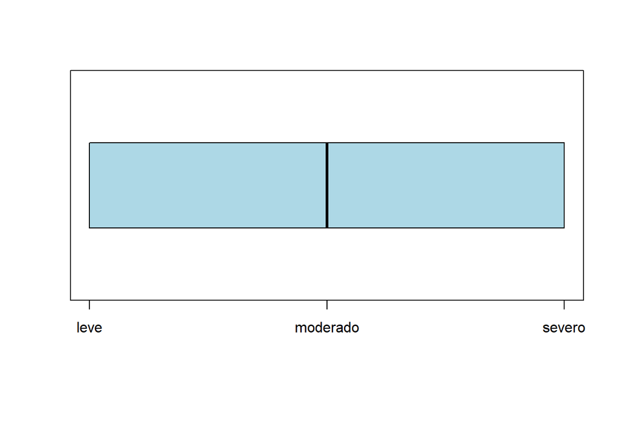

```r
par(mar=c(8,4,4,2))
boxplot(numerico_ord, horizontal = TRUE, col = "lightblue", xaxt = "n")
axis(1, at = 1:3, labels = niveles)
```

### Gráficos

Comenzamos a graficar.

#### Gráfica con el comando *barplot*

Generemos la gráfica de barras.

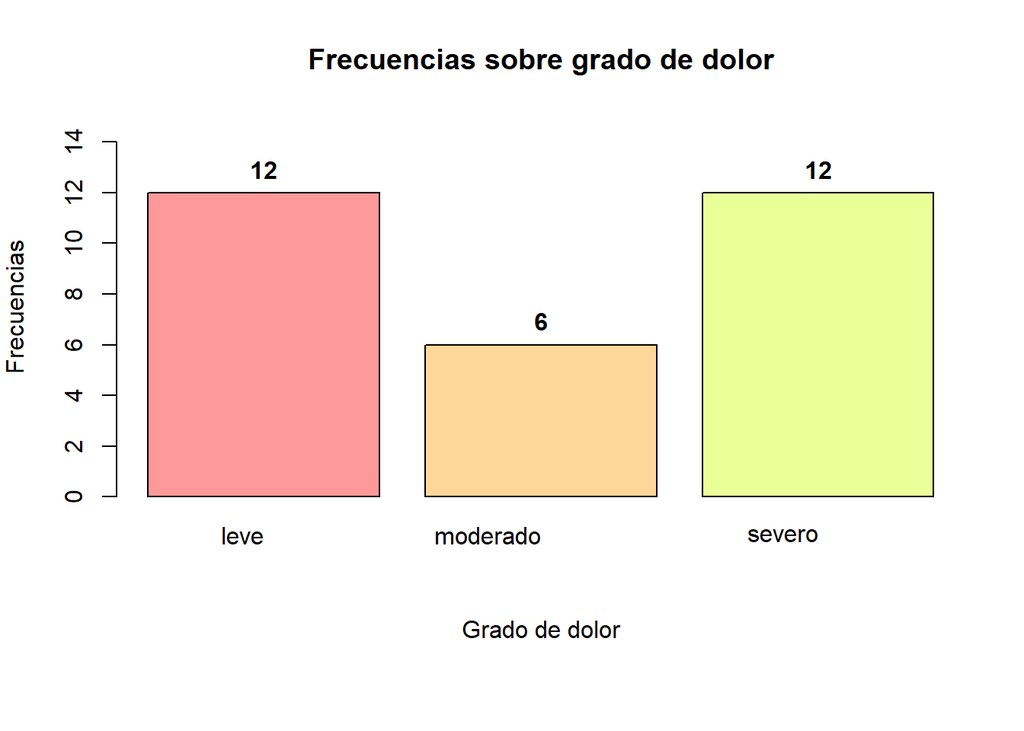

```r
par(mar=c(8,4,4,2))
gb<-barplot(contador, col=rainbow(10,0.4),
        main="Frecuencias sobre grado de dolor",
        xlab="",
        names.arg="",
        ylab="Frecuencias",
        ylim=c(0,15),
        )
title(xlab="Grado de dolor",line=4)

#Etiquetas rotadas
text(x=gb,
     y=par("usr")[3]-1.5,
     labels=names(contador),
     srt=0,
     adj=1,
     xpd=TRUE,
     cex=1)

# Agregar valores encima de cada barra
text(x=gb,
     y=contador,
     labels=contador,
     pos=3,
     cex=1,
     font=2)
```

#### Gráfica de porcentajes

Generamos la gráfica de porcentajes.

```r
par(mar=c(8,4,4,2))
tabla <- table(grado_dolor); (tabla)
```

```
## grado_dolor
##     leve moderado   severo
##       12        6       12
```

```r
porcentajes <-  round(prop.table(tabla)* 100, 1); (porcentajes)
```

```
## grado_dolor
##     leve moderado   severo
##       40       20       40
```

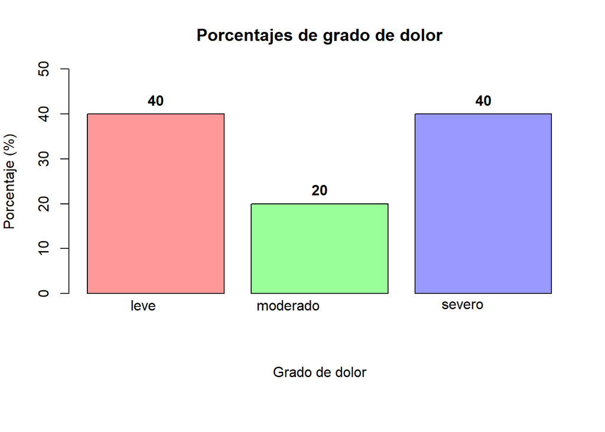

```r
gp<- barplot(porcentajes, col = rainbow(length(tabla),0.4),
    main = "Porcentajes de grado de dolor",
    xlab = "",
    names.arg="",
    ylab="Porcentaje (%)",
    ylim=c(0,50),
        )

title(xlab="Grado de dolor",line=4)

#Etiquetas rotadas
text(x=gb,
     y=par("usr")[3]-2.5,
     labels=names(contador),
     srt=0,
     adj=1,
     xpd=TRUE,
     cex=1)

# Agregar valores encima de cada barra
text(x=gp,
     y=porcentajes,
     labels=porcentajes,
     pos=3,
     cex=1,
     font=2)
```

#### Gráfica de pasteles

Generamos la gráfica de pasteles.

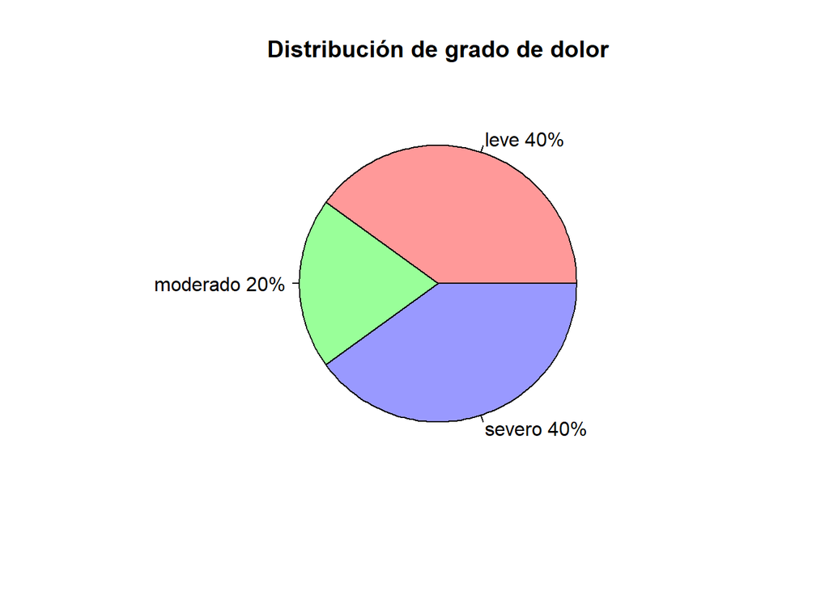

```r
pie(tabla,
    main = "Distribución de grado de dolor",
    col = rainbow(length(tabla),0.4),
    labels = paste0(names(tabla)," ",porcentajes, "%"))
```

#### Gráfica de ovija

Generamos la gráfica de ojiva

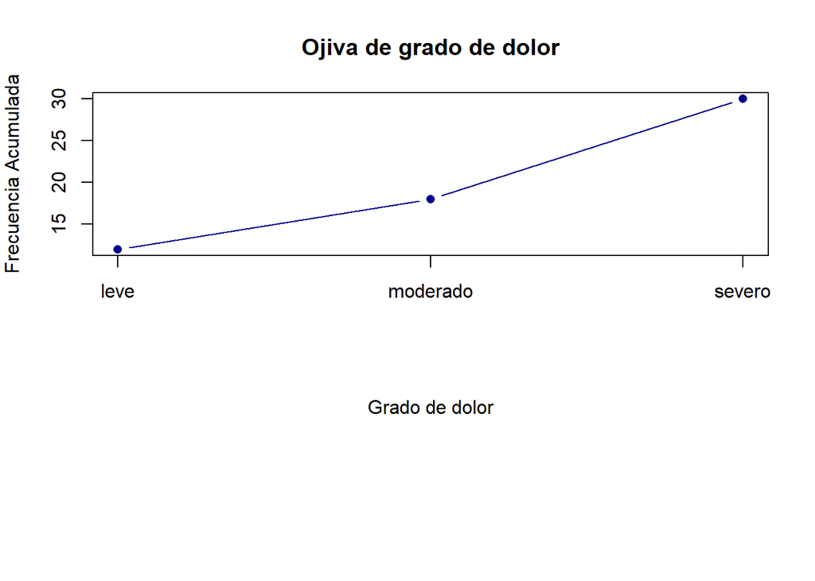

```r
par(mar=c(14,4,4,2))
frec_acum <- cumsum(table(factor(grado_dolor, levels = niveles)))
plot(frec_acum, type = "b", pch = 16, col = "darkblue",
     main = "Ojiva de grado de dolor",
     xlab = "",
     names.arg="",
     ylab = "Frecuencia Acumulada",
     xaxt = "n")
title(xlab="Grado de dolor",line=6)
axis(1, at = 1:3, labels = niveles)
```

```r
#---- Fin ----
```

## Ejercicio 7.4 Reseña de hoteles

### Datos

```r
resena_hotel <- c("4 estrellas", "5 estrellas", "1.5 estrellas", "4.5 estrellas", "5 estrellas", "4.5 estrellas", "2.5 estrellas", "4 estrellas", "4.5 estrellas", "1.5 estrellas", "3.5 estrellas", "1 estrella", "3.5 estrellas", "3 estrellas", "5 estrellas", "1.5 estrellas", "2 estrellas", "2 estrellas", "1.5 estrellas", "4.5 estrellas", "4.5 estrellas", "1.5 estrellas", "3.5 estrellas", "4 estrellas", "1 estrella", "4 estrellas", "4.5 estrellas", "3.5 estrellas", "1 estrella", "4 estrellas", "4 estrellas", "2 estrellas", "1 estrella", "4.5 estrellas", "1 estrella")
```

### Procesamiento de datos

Primero obtenemos un resumen de los datos generados

```r
summary(resena_hotel)
```

```
##    Length     Class      Mode
##        35 character character
```

Al ser variables de tipo Ordinal se pueden ordenar bajo un discriminante elegido, en este caso, de menor a mayor puntaje en las reseñas de un hotel.

### Frecuencias

Obtenemos las frecuencias de los datos.

```r
(resena_hotel) #Datos
```

```
##  [1] "4 estrellas"   "5 estrellas"   "1.5 estrellas" "4.5 estrellas"
##  [5] "5 estrellas"   "4.5 estrellas" "2.5 estrellas" "4 estrellas"
##  [9] "4.5 estrellas" "1.5 estrellas" "3.5 estrellas" "1 estrella"
## [13] "3.5 estrellas" "3 estrellas"   "5 estrellas"   "1.5 estrellas"
## [17] "2 estrellas"   "2 estrellas"   "1.5 estrellas" "4.5 estrellas"
## [21] "4.5 estrellas" "1.5 estrellas" "3.5 estrellas" "4 estrellas"
## [25] "1 estrella"    "4 estrellas"   "4.5 estrellas" "3.5 estrellas"
## [29] "1 estrella"    "4 estrellas"   "4 estrellas"   "2 estrellas"
## [33] "1 estrella"    "4.5 estrellas" "1 estrella"
```

```r
sort(resena_hotel) #Datos ordenados por clase
```

```
##  [1] "1 estrella"    "1 estrella"    "1 estrella"    "1 estrella"
##  [5] "1 estrella"    "1.5 estrellas" "1.5 estrellas" "1.5 estrellas"
##  [9] "1.5 estrellas" "1.5 estrellas" "2 estrellas"   "2 estrellas"
## [13] "2 estrellas"   "2.5 estrellas" "3 estrellas"   "3.5 estrellas"
## [17] "3.5 estrellas" "3.5 estrellas" "3.5 estrellas" "4 estrellas"
## [21] "4 estrellas"   "4 estrellas"   "4 estrellas"   "4 estrellas"
## [25] "4 estrellas"   "4.5 estrellas" "4.5 estrellas" "4.5 estrellas"
## [29] "4.5 estrellas" "4.5 estrellas" "4.5 estrellas" "4.5 estrellas"
## [33] "5 estrellas"   "5 estrellas"   "5 estrellas"
```

```r
contador <- table(resena_hotel) #Frecuencia de los datos
(contador)
```

```
## resena_hotel
##    1 estrella 1.5 estrellas   2 estrellas 2.5 estrellas   3 estrellas
##             5             5             3             1             1
## 3.5 estrellas   4 estrellas 4.5 estrellas   5 estrellas
##             4             6             7             3
```

### Proporciones

Obtenemos las proporciones.

```r
prop.table(table(resena_hotel)) #Proporciones
```

```
## resena_hotel
##    1 estrella 1.5 estrellas   2 estrellas 2.5 estrellas   3 estrellas
##    0.14285714    0.14285714    0.08571429    0.02857143    0.02857143
## 3.5 estrellas   4 estrellas 4.5 estrellas   5 estrellas
##    0.11428571    0.17142857    0.20000000    0.08571429
```

### Medidas de tendencia central

#### Moda

Obtenemos la moda

```r
# Función para detectar modalidad
max_frecuencia <- max(contador)
modas <- names(contador)[contador == max_frecuencia]

# Identificar e imprimir resultado
if(length(modas) == 1) {
  cat("UNIMODAL - Moda:", modas)
} else if(length(modas) == 2) {
  cat("BIMODAL - Modas:", paste(modas, collapse = " y "))
} else {
  cat("Hay más de dos clases con mayor frecuencia por lo tanto no hay moda")
}
```

```
## UNIMODAL - Moda: 4.5 estrellas
```

#### Mediana

Obtenemos la mediana

```r
mediana_hotel <- function(resena_hotel) {
  niveles <- c("1 estrella", "1.5 estrellas", "2 estrellas", "2.5 estrellas",
               "3 estrellas", "3.5 estrellas", "4 estrellas", "4.5 estrellas", "5 estrellas") #Con esto ordenamos nuestras clases de menor a mayor puntaje en reseñas de hoteles

  # Convertir a numérico, ordenar y reconvertir a texto
  numerico_ord <- sort(sapply(resena_hotel, function(x) which(niveles == x)))
  (numerico_ord)
  texto_ord <- niveles[numerico_ord]
  cat("Datos ordenados:   ", paste(texto_ord, collapse = ", "), "\n")

  # Calcular mediana
  mediana<- median(numerico_ord)
  resultado <- niveles[round(mediana)]

  cat("La mediana es:", resultado, "\n")
  return(resultado)
}

resultado <- mediana_hotel(resena_hotel)
```

```
## Datos ordenados:    1 estrella, 1 estrella, 1 estrella, 1 estrella, 1 estrella, 1.5 estrellas, 1.5 estrellas, 1.5 estrellas, 1.5 estrellas, 1.5 estrellas, 2 estrellas, 2 estrellas, 2 estrellas, 2.5 estrellas, 3 estrellas, 3.5 estrellas, 3.5 estrellas, 3.5 estrellas, 3.5 estrellas, 4 estrellas, 4 …
## La mediana es: 3.5 estrellas
```

#### Media

A pesar de tener datos que se pueden ordenar, no se puede tener una media debido a que no tenemos datos numéricos con los cuales calcular.

### Medidas de localización

#### Cuartiles

```r
niveles <- c("1 estrella", "1.5 estrellas", "2 estrellas", "2.5 estrellas",
               "3 estrellas", "3.5 estrellas", "4 estrellas", "4.5 estrellas", "5 estrellas")

numerico <- sapply(resena_hotel, function(x) which(niveles == x))
numerico_ord <- sort(numerico)

q1 <- niveles[round(quantile(numerico_ord, 0.25))]
(q1)
```

```
## [1] "1.5 estrellas"
```

```r
q2 <- niveles[round(quantile(numerico_ord, 0.50))]
(q2)
```

```
## [1] "3.5 estrellas"
```

```r
q3 <- niveles[round(quantile(numerico_ord, 0.75))]
(q3)
```

```
## [1] "4.5 estrellas"
```

Calculemos el valor máximo y el valor mínimo para los datos

```r
mi_min <- min(resena_hotel);
(mi_min)
```

```
## [1] "1 estrella"
```

```r
mi_max <- max(resena_hotel);
(mi_max)
```

```
## [1] "5 estrellas"
```

### Diagrama de caja y brazos

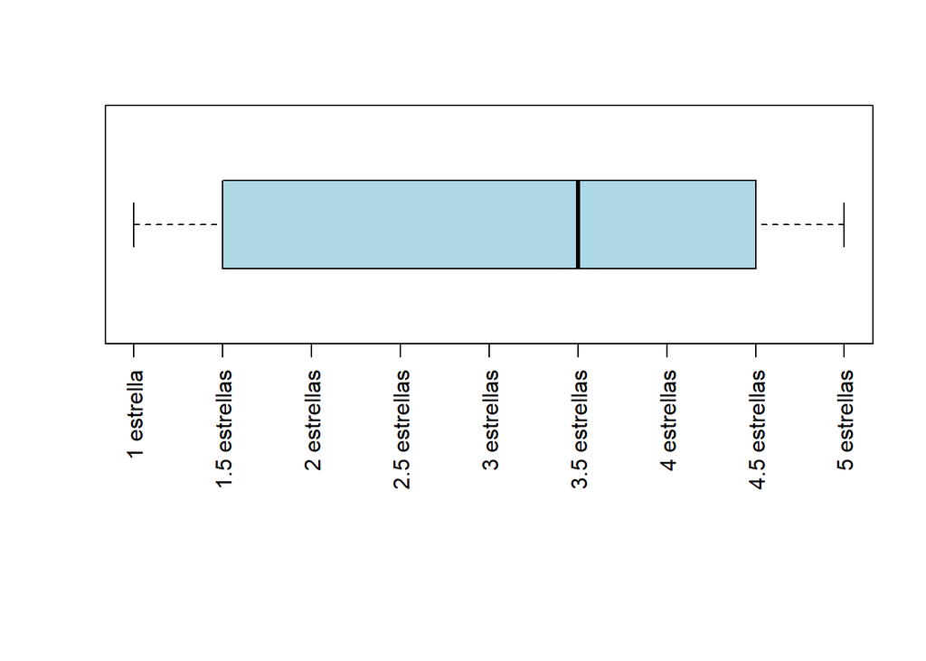

```r
par(mar=c(12,4,4,2))
boxplot(numerico_ord, horizontal = TRUE, col = "lightblue", xaxt = "n")
axis(1, at = 1:9, labels = niveles, las=2)
```

### Gráficos

Comenzamos a graficar.

#### Gráfica con el comando *barplot*

Generemos la gráfica de barras.

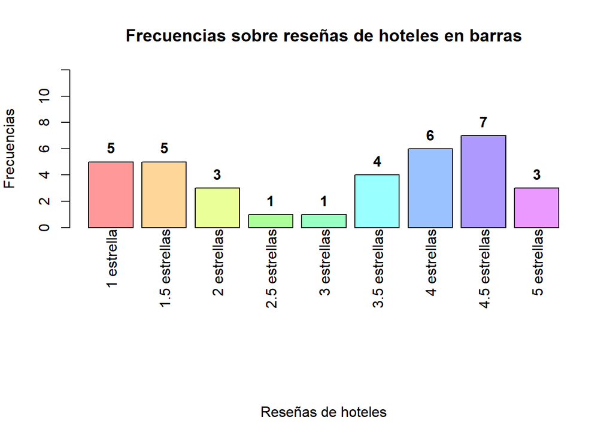

```r
par(mar=c(12,4,4,2))
gb<-barplot(contador, col=rainbow(10,0.4),
        main="Frecuencias sobre reseñas de hoteles en barras",
        xlab="",
        names.arg="",
        ylab="Frecuencias",
        ylim=c(0,12),
        )
title(xlab="Reseñas de hoteles",line=10)

#Etiquetas rotadas
text(x=gb,
     y=par("usr")[3]-0.1,
     labels=names(contador),
     srt=90,
     adj=1,
     xpd=TRUE,
     cex=1)

# Agregar valores encima de cada barra
text(x=gb,
     y=contador,
     labels=contador,
     pos=3,
     cex=1,
     font=2)
```